**Name:** Emad Takla

**DAND P2**

**Dataset chosen:** Titanic

# Setup

## Headers to be used throughout the project:

```python
import unicodecsv
import pandas as pd
import numpy as np
import matplotlib.pyplot as plt
import seaborn as sns
import scipy.stats
from IPython.display import HTML
from IPython.display import display_html
```

## Special Commands

```python
#Plot all figures within the html page
%pylab inline

#Make display better, like printing dataframes as tables
pd.set_option('display.notebook_repr_html', True)
```

## Importing Data

```python
titanic_all_data = pd.read_csv('./titanic_data.csv')
```

## Supporting Functions:

A function to map age into generation buckets: Child (0 to 16 years old), Adult (17 to 49 years old) and elderly (50 years old and over)

```python
def age_to_generation(age):
    #Check if the input is negative, return an error
    if age < 0:
        return 'Invalid age'
    #If younger than 17, then it is classified as a child
    if age < 17:
        return 'Child'
    #else if it is between 18 and 49 (both inclusive), the passed age is for an adult
    if age < 50:
        return 'Adult'
    #Else if, the person is an elderly
    if age >= 50:
        return 'Elderly'
    #Else, the input age was unspecified (Blank cell, NaN)
    return 'Unspecified age'
```

A function to strip the last name from the column 'Name' The assumption is that the format is as follows: 'last_name, title. first_name (Alias\Maiden Name)'

```python
def get_last_name(full_name):
    return full_name.split(',')[0]
```

A function to plot a population pyramid, a horizontal histogram bar chart plotted back to back

```python
# Plotting code coming from http://stackoverflow.com/questions/27694221/using-python-libraries-to-plot-two-horizontal-bar-charts-sharing-same-y-axis
#Binning Code coming from http://stackoverflow.com/questions/21441259/pandas-groupby-range-of-values

def plot_population_pyramid(bins, left_title, left_data, right_title, right_data, largest_x_value):
    fig, axes = plt.subplots(ncols=2, sharey=True)

    #largest_x_value:
    #this variable will be used to preserve scale. If not, the two graphs will extend to the maximum value of the dataset,
    #and will be visually misleading
    #largest_x_value = max(left_data.max(), right_data.max())

    axes[0].barh(bins, left_data, align='center')
    axes[0].set(title=left_title)
    axes[0].set_xlim(0, largest_x_value)

    axes[1].barh(bins, right_data, align='center')
    axes[1].set(title=right_title)
    axes[1].set_xlim(0, largest_x_value)

    axes[0].invert_xaxis()
    axes[0].set(yticks=bins)
    axes[0].yaxis.tick_right()
```

Two functions to count the number of survivors\victims within a passed GroupBy object. **The Function Accepts A GroupBy Object, Not a DataFrame!**

The need for the function came when groupby can get an input that had by chance all victims\survivors, and there was no other group for the missing opposite value. This created index errors when I programmatically looped over the groups, and I had to check if the group was present in the data structure before using it

```python
def get_surviving_count(group_obj):
    #The values in Survived are either 1 or 0, with 1 indicating survivors
    if 1 in group_obj.groups.keys():
        return group_obj.get_group(1)['PassengerId'].count()
    else:
        return 0
```

```python
def get_victim_count(group_obj):
    #The values in Survived are either 1 or 0, with 0 indicating victims
    if 0 in group_obj.groups.keys():
        return group_obj.get_group(0)['PassengerId'].count()
    else:
        return 0
```

Graphing Helper Functions and Variables.

```python
gender_colors = ['hotpink','dodgerblue']
survival_colors = ['red', 'limegreen']
```

The following function accepts a groupby object, that must group its original input only by Survived (ie only at maximum two groups, group 0 (victim) and group 1 (survived)

```python
def plot_survival_pie_chart(group_obj, label):
    graph_label = []
    survival_colors = []

    if 0 in group_obj.groups.keys():
        graph_label.append('Victim')
        survival_colors.append('red')
    if 1 in group_obj.groups.keys():
        graph_label.append('Survived')
        survival_colors.append('limegreen')

    group_obj['PassengerId'].count().plot.pie(label = label, autopct='%1.1f%%', colors=survival_colors,labels=graph_label)
```

A function to get the count of passengers in a passed dataframe

```python
def get_count(df):
    return df['PassengerId'].count()
```

A function to make subplots. It will be overloaded to have a version where we can pass the labels parameter

```python
def draw_pie_subplot(groupby_data, subplot_position, graph_label,  graph_type):
    graph_colors = []
    if(graph_type == 'SURVIVAL_GRAPH'):
        graph_colors = survival_colors
    elif(graph_type == 'GENDER_GRAPH'):
        graph_colors = gender_colors

    fig.add_subplot(subplot_position)

    #If it's a survival graph, use the already created function to plot it
    if (graph_type == 'SURVIVAL_GRAPH'):
        plot_survival_pie_chart(groupby_data ,graph_label )

    #Default colors. Do not pass the colors parameter to the plotting function
    elif graph_type == 'DEFAULT':
        get_count(groupby_data).plot.pie(label = graph_label, autopct='%1.1f%%')

    else:
        get_count(groupby_data).plot.pie(label = graph_label, \
                                     autopct='%1.1f%%',\
                                     colors = graph_colors)
    plt.axis('equal')
```

# Questions

## Q1: What is the effect of Traveling With First Degree Relatives Over the Survival of a Passenger ?

http://www.durhamcollege.ca/wp-content/uploads/STAT_nullalternate_hypothesis.pdf

- The question that will be investigated in this analysis is: if a passenger was traveling without a family (ie both SibSp and Parch were equal to zero), did he have a higher\lower chance of survival ? Was having a family on board an advantage, disadvantage or irrelevant for the survival of a passenger ?

**Null Hypothesis:** There is NO difference in the survival rate of passengers traveling with their immediate family and that of passengers traveling alone.

**Alternate Hypothesis:** There IS a difference in the survival rate of passengers traveling with their immediate family and that of passengers traveling alone.

**α: 0.05**

## Q2: Is It Possible From The Provided Data To Identify Same Family Members?

This is more of a data investigation question, not a statistical inference one. The data provides the last names, ages, traveling class and companionship (Spouses, Sibling - Parents, Children). Are these enough to make (partial) educated guesses about the family members? And if there is a success to do that, can we infer if having a bigger family improved the chances of survival ? (Possibly, since the rest of the family would pressure the crew to allow their left-behind family member on board of the life boats)

# Data Wrangling

## New Fields to the Data

An interesting feature to show, is the generation to which the passenger belongs. There shall be three categories for that parameter (Child, Adult and Elderly) based on their age range. The breakdown is as follows

- Child: 16 years old >= Age >= 0 years old
- Adult: 49 years old >= Age >= 17 years old
- Elderly: Age >= 50 years old

Any other values like NaN, negative numbers, blank fields, non-numerical values..etc will be noted as "Unspecified age"

The 'isSolo' field will be used to see if a passenger is traveling with his\her family or not. Here are the criterias used:

- A solo traveler is a traveler whose SibSp\Parch fields are equal to zero.
- A child cannot be a solo traveler, even if the SibSp\Parch fields are equal to zero.
- **Just a word of caution when interpreting the isSolo field:** isSolo does not mean that the traveler was traveling totally alone, they can be traveling with friends for example.

The total number of companions is the sum of the fields Parch and SibSp. It will be used for creating some descriptive statitistics about companionship

The 'LastName' field simply extracts the last name of the passenger from the full name provided. This will be useful in answering the second question.

```python
#Adding the generation data field to the table. The generation can have three values: Child, Adult or Elderly
#The buckets ranges were arbitrarily chosen
titanic_all_data['Generation']  = titanic_all_data.loc[:,'Age'].apply(age_to_generation)

"""
If the traveler is a child (Under 17 years old), then automatically they are not a solo traveler (Can be traveling with a
nanny or a close family-friend..etc). Or, if the traveler has a non-zero value in any of SibSp and Parch, then they are not
solo Otherwise, they are a solo passenger, traveling alone
"""
#This one was tough, using the 'and' operator raised a ValueError, and it took me a while to find out that
#I should substitute it with bitwise &
titanic_all_data['isSolo'] = (titanic_all_data['SibSp'] + titanic_all_data['Parch'] == 0) & \
                             (titanic_all_data['Generation'] != 'Child')

titanic_all_data['TotalCompanions'] = titanic_all_data['Parch'] + titanic_all_data['SibSp']


#Stripping the last name of the passengers. This will be used to determine which passengers probably belong to the same family
titanic_all_data['LastName'] = titanic_all_data.loc[:,'Name'].apply(get_last_name)
```

## Data Slicing

### Extracting General Data About the Passengers

```python
#Passengers by Gender
male_passengers = titanic_all_data[titanic_all_data['Sex'] == 'male']
female_passengers = titanic_all_data[titanic_all_data['Sex'] == 'female']

#Passengers by Generation
children_passengers = titanic_all_data[ titanic_all_data['Generation'] == 'Child' ]
adult_passengers = titanic_all_data[ titanic_all_data['Generation'] == 'Adult' ]
elderly_passengers = titanic_all_data[ titanic_all_data['Generation'] == 'Elderly' ]

#Passengers by Survival
surviving_passengers = titanic_all_data[ titanic_all_data['Survived'] == 1 ]
victim_passengers = titanic_all_data[ titanic_all_data['Survived'] == 0 ]
```

### Data Groups:

In my opinion, groups are very straight forward when it comes to plot; but slicing dataframes is better for calculations. Just easier for me.

```python
passengers_by_gender = titanic_all_data.groupby('Sex')
passengers_by_generation = titanic_all_data.groupby('Generation')
passengers_by_class = titanic_all_data.groupby('Pclass')
passengers_by_survival = titanic_all_data.groupby('Survived')
passengers_by_companionship = titanic_all_data.groupby('isSolo')

passengers_by_class_and_gender = titanic_all_data.groupby(['Pclass', 'Sex'])
passengers_by_class_and_generation = titanic_all_data.groupby(['Pclass', 'Generation'])
passengers_by_class_and_survival = titanic_all_data.groupby(['Pclass', 'Survived'])
passengers_by_generation_and_gender = titanic_all_data.groupby(['Generation', 'Sex'])
```

### Slicing The Passengers' Parameters According to their Traveling Class

I have followed the instructions in the previous review by using groupby instead of slicing. However, I still cannot see the advantage in that. In fact, I think that the first way was more readable. For example: first_class_passengers[ first_class_passengers['Survived'] == 0 ] vs passengers_by_class_and_survival.get_group( (1,0) )

```python
#Passengers by class
########################################################################################################################
#First Class Data Splitting:
first_class_passengers = passengers_by_class.get_group(1)

#Gender
first_class_male_passengers = passengers_by_class_and_gender.get_group( (1,'male') )
first_class_female_passengers = passengers_by_class_and_gender.get_group( (1,'female') )
#Children
first_class_children_passengers = passengers_by_class_and_generation.get_group( (1, 'Child') )
first_class_children_male_passengers = first_class_children_passengers.groupby('Sex').get_group('male')
first_class_children_female_passengers = first_class_children_passengers.groupby('Sex').get_group('female')
#Adults
first_class_adult_passengers = passengers_by_class_and_generation.get_group( (1, 'Adult') )
first_class_adult_male_passengers = first_class_adult_passengers.groupby('Sex').get_group('male')
first_class_adult_female_passengers = first_class_adult_passengers.groupby('Sex').get_group('female')
#Elderly
first_class_elderly_passengers = passengers_by_class_and_generation.get_group( (1, 'Elderly') )
first_class_elderly_male_passengers = first_class_elderly_passengers.groupby('Sex').get_group('male')
first_class_elderly_female_passengers = first_class_elderly_passengers.groupby('Sex').get_group('female')

#First Class Survival
first_class_survivors = passengers_by_class_and_survival.get_group( (1,1) )
first_class_victims = passengers_by_class_and_survival.get_group( (1,0) )

########################################################################################################################
#Second Class Data Splitting:
second_class_passengers = passengers_by_class.get_group(2)

#Gender
second_class_male_passengers = passengers_by_class_and_gender.get_group( (2,'male') )
second_class_female_passengers = passengers_by_class_and_gender.get_group( (2,'female') )
#Children
second_class_children_passengers = passengers_by_class_and_generation.get_group( (2, 'Child') )
second_class_children_male_passengers = second_class_children_passengers.groupby('Sex').get_group('male')
second_class_children_female_passengers = second_class_children_passengers.groupby('Sex').get_group('female')
#Adults
second_class_adult_passengers = passengers_by_class_and_generation.get_group( (2, 'Adult') )
second_class_adult_male_passengers = second_class_adult_passengers.groupby('Sex').get_group('male')
second_class_adult_female_passengers = second_class_adult_passengers.groupby('Sex').get_group('female')
#Elderly
second_class_elderly_passengers = passengers_by_class_and_generation.get_group( (2, 'Elderly') )
second_class_elderly_male_passengers = second_class_elderly_passengers.groupby('Sex').get_group('male')
second_class_elderly_female_passengers = second_class_elderly_passengers.groupby('Sex').get_group('female')

#second Class Survival
second_class_survivors = passengers_by_class_and_survival.get_group( (2,1) )
second_class_victims = passengers_by_class_and_survival.get_group( (2,0) )

########################################################################################################################
#Third Class Data Splitting:
third_class_passengers = passengers_by_class.get_group(3)

#Gender
third_class_male_passengers = passengers_by_class_and_gender.get_group( (3,'male') )
third_class_female_passengers = passengers_by_class_and_gender.get_group( (3,'female') )
#Children
third_class_children_passengers = passengers_by_class_and_generation.get_group( (3, 'Child') )
third_class_children_male_passengers = third_class_children_passengers.groupby('Sex').get_group('male')
third_class_children_female_passengers = third_class_children_passengers.groupby('Sex').get_group('female')
#Adults
third_class_adult_passengers = passengers_by_class_and_generation.get_group( (3, 'Adult') )
third_class_adult_male_passengers = third_class_adult_passengers.groupby('Sex').get_group('male')
third_class_adult_female_passengers = third_class_adult_passengers.groupby('Sex').get_group('female')
#Elderly
third_class_elderly_passengers = passengers_by_class_and_generation.get_group( (1, 'Elderly') )
third_class_elderly_male_passengers = third_class_elderly_passengers.groupby('Sex').get_group('male')
third_class_elderly_female_passengers = third_class_elderly_passengers.groupby('Sex').get_group('female')

#third Class Survival
third_class_survivors = passengers_by_class_and_survival.get_group( (3,1) )
third_class_victims = passengers_by_class_and_survival.get_group( (3,0) )
```

# Data Exploration and Analysis

### Miscellaneous Data Count Computation

```python
sample_size = get_count(titanic_all_data)
male_count = get_count(passengers_by_gender.get_group('male'))
female_count = get_count(passengers_by_gender.get_group('female'))

children_count = get_count(children_passengers)
children_male_count = get_count(passengers_by_generation_and_gender.get_group(('Child', 'male')) )
children_female_count = get_count(passengers_by_generation_and_gender.get_group(('Child', 'female')) )

adult_count = get_count(adult_passengers)
adult_male_count = get_count( passengers_by_generation_and_gender.get_group(('Adult', 'male')) )
adult_female_count = get_count( passengers_by_generation_and_gender.get_group(('Child', 'female')) )

elderly_count = get_count(elderly_passengers)
elderly_male_count = get_count( passengers_by_generation_and_gender.get_group(('Elderly', 'male')) )
elderly_female_count = get_count( passengers_by_generation_and_gender.get_group(('Elderly', 'female')) )

first_class_count = get_count(first_class_passengers)
first_class_male_count = get_count(first_class_male_passengers)
first_class_female_count = get_count(first_class_female_passengers)
first_class_children_count = get_count(first_class_children_passengers)
first_class_children_male_count = get_count(first_class_children_male_passengers)
first_class_children_female_count = get_count(first_class_children_female_passengers)
first_class_adult_count = get_count(first_class_adult_passengers)
first_class_adult_male_count = get_count(first_class_adult_male_passengers)
first_class_adult_female_count = get_count(first_class_adult_female_passengers)
first_class_elderly_count = get_count(first_class_elderly_passengers)
first_class_elderly_male_count = get_count(first_class_elderly_male_passengers)
first_class_elderly_female_count = get_count(first_class_elderly_female_passengers)

second_class_count = get_count(second_class_passengers)
second_class_male_count = get_count(second_class_male_passengers)
second_class_female_count = get_count(second_class_female_passengers)
second_class_children_count = get_count(second_class_children_passengers)
second_class_children_male_count = get_count(second_class_children_male_passengers)
second_class_children_female_count = get_count(second_class_children_female_passengers)
second_class_adult_count = get_count(second_class_adult_passengers)
second_class_adult_male_count = get_count(second_class_adult_male_passengers)
second_class_adult_female_count = get_count(second_class_adult_female_passengers)
second_class_elderly_count = get_count(second_class_elderly_passengers)
second_class_elderly_male_count = get_count(second_class_elderly_male_passengers)
second_class_elderly_female_count = get_count(second_class_elderly_female_passengers)

third_class_count = get_count(third_class_passengers)
third_class_male_count = get_count(third_class_male_passengers)
third_class_female_count = get_count(third_class_female_passengers)
third_class_children_count = get_count(third_class_children_passengers)
third_class_children_male_count = get_count(third_class_children_male_passengers)
third_class_children_female_count = get_count(third_class_children_female_passengers)
third_class_adult_count = get_count(third_class_adult_passengers)
third_class_adult_male_count = get_count(third_class_adult_male_passengers)
third_class_adult_female_count = get_count(third_class_adult_female_passengers)
third_class_elderly_count = get_count(third_class_elderly_passengers)
third_class_elderly_male_count = get_count(third_class_elderly_male_passengers)
third_class_elderly_female_count = get_count(third_class_elderly_female_passengers)
```

### Finding Out Missing Fields

```python
#The PassengerId is present for all the passengers, but there are some columns that has some missing values. Which columns
#are they?
for column_id in titanic_all_data.columns.values:
    column_non_NaN_count = titanic_all_data[column_id].count()
    if column_non_NaN_count != sample_size:
        print str(column_id) + ": missing " + str(sample_size - column_non_NaN_count) + " values"
```

```
Age: missing 177 values
Cabin: missing 687 values
Embarked: missing 2 values
```

I am going to leave the blank cells empty, until I need to fill them with a value - if needed. For the time being, I am not sure for example if I should fill the missing ages with the mean age or just treat them as zeros. Let us wait and see what need would arise.

### A word of caution about the ages in this data set

Not all passengers have known ages. An assumption: that the passengers whose age is not know are equally distributed along all age range, so the effect of missing this piece of information is minimal. For curiosity, below is provided the percentages of survivors and victims whose ages are unknown:

```python
#Get the count of both survivors and victims whose age is null
survivors_without_age_count = surviving_passengers['Age'].isnull().sum()
victims_without_age_count = victim_passengers['Age'].isnull().sum()

#Count the total of survivors and victims, so we can calculate the percentage of passengers with missing ages
total_survivors_count = get_count(surviving_passengers)
total_victims_count = get_count(victim_passengers)

print "Percentage of survivors with missing age: ", float(survivors_without_age_count)*100/total_survivors_count,"%"
print "Percentage of victims with missing age:   ", float(victims_without_age_count)*100/total_victims_count,"%"
```

```
Percentage of survivors with missing age:  15.2046783626 %
Percentage of victims with missing age:    22.7686703097 %
```

## Demographics

**Some default columns, will be used as a dataframe column. These dataframes will be used to display the data in an HTML table format. Although there are alternatives to this, using the dataframe as a way to display tables was the easiest one.**

### Quick Statistics, All The Sample

#### Sample's Gender Make Up

|  | Male | Female | Total |
| --- | --- | --- | --- |
| count | 577 | 314 | 891 |

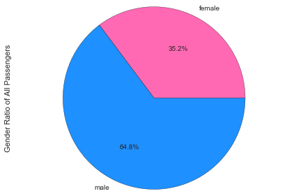

```python
#Rows to be displayed
rows = [{male_count, female_count, sample_size}]

#create the data frame, in preparation for HTML table display
df = pd.DataFrame(rows, columns=['Male', 'Female',"Total"], index=["count"])

#Display the dataframe as an HTML table. I had to use this function since just writing "df" on a single line
#will not display the table when there is a plot coming afterwards in the same cell.
display_html(df)

#Plot the pie chart, all passengers by gender
passengers_by_gender.size().plot.pie(label="Gender Ratio of All Passengers", autopct='%1.1f%%', colors=gender_colors)
plt.axis('equal')

#This command removes some floating numbers that appears
plt.tight_layout()
```

#### Sample's Generation Make Up:

|  | Adult | Children | Elderly | Unspecified Age |
| --- | --- | --- | --- | --- |
| count | 540 | 100 | 74 | 177 |

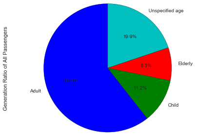

```python
#I had a problem creating the dataframe in the same manner as the previous one, since the order was not preserved
#(ie Children count was below column elderly for example)
unspecified_age_count = get_count(passengers_by_generation.get_group("Unspecified age"))

#Create the dataframe in preparation for HTML table display
df = pd.DataFrame({'Children':children_count, 'Adult':adult_count,'Elderly':elderly_count,'Unspecified Age':unspecified_age_count},\
                   index=["count"])

#Display the table
display_html(df)

#Plot the pie chart of all the passengers, grouped by their generation
passengers_by_generation.size().plot.pie(label="Generation Ratio of All Passengers", autopct='%1.1f%%', startangle=90)
plt.axis('equal')

#This command removes some floating numbers that appears
plt.tight_layout()
```

#### Population Pyramid

The population pyramid of the passengers. Naturally, this excludes the passengers whose age was missing, so the total count here will not be equal to that of the whole sample.

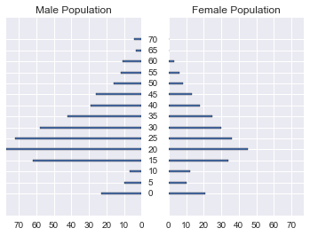

```python
#Age bins, from zero to 75 years old with 5 years increment
age_bins = range(0,75,5)

#Group both genders according to the age bin
grouped_female_ages = get_count(female_passengers.groupby( pd.cut( female_passengers["Age"], np.arange(0, 80, 5) ) ))
grouped_male_ages =   get_count(male_passengers.groupby( pd.cut( male_passengers["Age"], np.arange(0, 80, 5) ) ))

#Get the highest count. Required so that both plots would keep the same scale when displayed
largest_x_value = max(grouped_female_ages.max(), grouped_male_ages.max())

#A helper function defined in the beginning of the file. Plots the age pyramid
plot_population_pyramid(age_bins, "Male Population", grouped_male_ages, "Female Population", grouped_female_ages, largest_x_value)
```

A noticeable mode is seen on the 20 years old bucket, in both genders.

#### Sample's Class Make Up

|  | First Class | Second Class | Third Class |
| --- | --- | --- | --- |
| count | 216 | 184 | 491 |

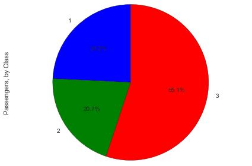

```python
#Create the dataframe in preparation for HTML table display
df = pd.DataFrame({'First Class':first_class_count,\
                   'Second Class':second_class_count,\
                   'Third Class':third_class_count}, index=["count"])

#Display the table
display_html(df)

#Plot the pie chart of all the passengers, grouped by class
passengers_by_class.size().plot.pie(label="Passengers, by Class", autopct='%1.1f%%', startangle=90)
plt.axis('equal')

#This command removes some floating numbers that appears
plt.tight_layout()
```

#### Sample's Survival

|  | Survivors | Victims |
| --- | --- | --- |
| count | 342 | 549 |

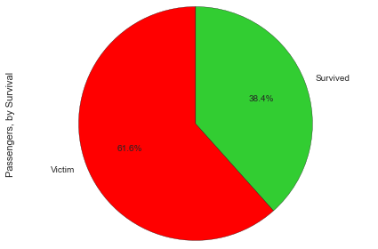

```python
#Create the dataframe in preparation for HTML table display
df = pd.DataFrame({'Survivors': get_count(surviving_passengers) ,\
                   'Victims':   get_count(victim_passengers) }, index=["count"])

#Display the table
display_html(df)

#Plot the pie chart of all the passengers, grouped by class
#I am not goin to use the custom survival pie chart because I want to make the start angle = 90 degrees
passengers_by_survival.size().plot.pie(label="Passengers, by Survival", \
                                       autopct='%1.1f%%', \
                                       labels=['Victim', 'Survived'], \
                                       startangle=90,\
                                       colors=survival_colors)

plt.axis('equal')

#This command removes some floating numbers that appears
plt.tight_layout()
```

#### Sample's Companionship (Passengers Traveling Alone vs Passengers Traveling With First Degree Family Member(s) )

[output not shown]

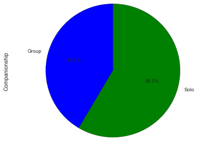

```python
#Create the dataframe in preparation for HTML table display
df = pd.DataFrame({'In Group':get_count(surviving_passengers),\
                   'Solo   ': get_count(victim_passengers) }, index=["count"])

#Display the table
display_html(df)

#Plot the pie chart of all the passengers, grouped by class
get_count(titanic_all_data.groupby('isSolo')).plot.pie(labels=['Group', 'Solo'], \
                                                                   label = "Companionship", \
                                                                   autopct='%1.1f%%', \
                                                                   startangle=90)
plt.axis('equal')

#This command removes some floating numbers that appears
plt.tight_layout()
```

## Exploring The Data From the Generation Point of View

### Sample's Generation, Broken Down by Gender

[output not shown]

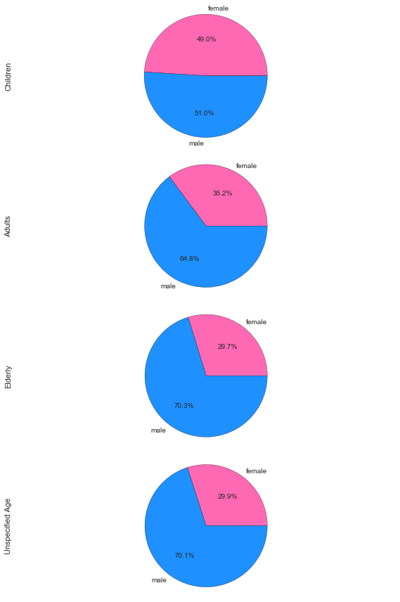

```python
#Compute the unspecified age parameters.
unspecified_age_by_gender = passengers_by_generation.get_group("Unspecified age").groupby('Sex')
unspecified_age_male_count = get_count(unspecified_age_by_gender.get_group('male'))
unspecified_age_female_count = get_count(unspecified_age_by_gender.get_group('female'))

#Create the dataframe of Children, Adult, Elderly and Unspecified age's gender make up.
df = pd.DataFrame({'Children':[children_male_count, children_female_count], \
                   'Adult':[adult_male_count, adult_female_count],\
                   'Elderly':[elderly_male_count, elderly_female_count],\
                   'Unspecified Age':[unspecified_age_male_count, unspecified_age_female_count]}, \
                  index=["Male Count", "Female Count"])

#Display the dataframe as an HTML table
display_html(df)

#STart a multiplot plot
fig = plt.figure(figsize=(8,12))

#Children gender ratio pie plot
draw_pie_subplot( passengers_by_generation.get_group("Child").groupby('Sex'), 411, 'Children', 'GENDER_GRAPH')

#Adults gender ratio pie plot
draw_pie_subplot( passengers_by_generation.get_group("Adult").groupby('Sex'), 412, 'Adults', 'GENDER_GRAPH')

#Elderly  gender ratio pie plot
draw_pie_subplot( passengers_by_generation.get_group("Elderly").groupby('Sex'), 413, 'Elderly', 'GENDER_GRAPH')


#Unspecified age gender ratio pie plot
draw_pie_subplot( passengers_by_generation.get_group("Unspecified age").groupby('Sex'), 414, 'Unspecified Age', 'GENDER_GRAPH')

plt.tight_layout()
```

**Only the children passengers seemed to have a balanced proportion of both gender, all the rest have a higher proportion of men.**

### Survival, Broken Down by Generation

|  | Adult | Children | Elderly | Unspecified Age |
| --- | --- | --- | --- | --- |
| Survivors Count | 208 | 55 | 27 | 52 |
| Victims Count | 332 | 45 | 47 | 125 |

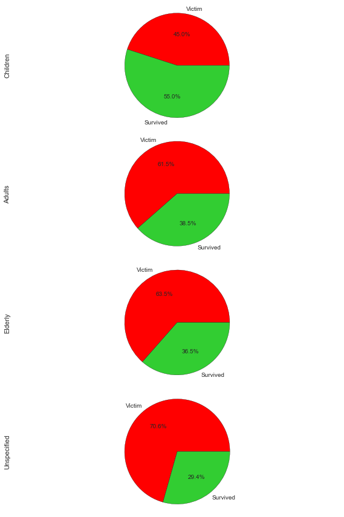

```python
#Group each generation by survival.
children_by_survival = children_passengers.groupby('Survived')
adult_by_survival = adult_passengers.groupby('Survived')
elderly_by_survival = elderly_passengers.groupby('Survived')
unspecified_age_by_survival = passengers_by_generation.get_group("Unspecified age").groupby('Survived')

#Get the count of each group's survival
children_survived = get_count(children_by_survival.get_group(1))
children_victim = get_count(children_by_survival.get_group(0))

adult_survived = get_count(adult_by_survival.get_group(1))
adult_victim = get_count(adult_by_survival.get_group(0))

elderly_survived = get_count(elderly_by_survival.get_group(1))
elderly_victim = get_count(elderly_by_survival.get_group(0))

unspecified_age_survived = get_count(unspecified_age_by_survival.get_group(1))
unspecified_age_victim = get_count(unspecified_age_by_survival.get_group(0))



#Create the dataframe of Children, Adult, Elderly and Unspecified age's survival make up.
df = pd.DataFrame({'Children':[children_survived, children_victim], \
                   'Adult':[adult_survived, adult_victim],\
                   'Elderly':[elderly_survived, elderly_victim],\
                   'Unspecified Age':[unspecified_age_survived, unspecified_age_victim]}, \
                  index=["Survivors Count", "Victims Count"])

#Display the dataframe as an HTML table
display_html(df)

#Start a multiplot plot
fig = plt.figure(figsize=(8,12))

#Children gender ratio pie plot
draw_pie_subplot( passengers_by_generation.get_group("Child").groupby('Survived'), 411, 'Children', 'SURVIVAL_GRAPH')

#Adults gender ratio pie plot
draw_pie_subplot( passengers_by_generation.get_group("Adult").groupby('Survived'), 412, 'Adults', 'SURVIVAL_GRAPH')

#Elderly  gender ratio pie plot
draw_pie_subplot( passengers_by_generation.get_group("Elderly").groupby('Survived'), 413, 'Elderly', 'SURVIVAL_GRAPH')

#Unspecified age gender ratio pie plot
draw_pie_subplot( passengers_by_generation.get_group("Unspecified age").groupby('Survived'), 414, 'Unspecified', 'SURVIVAL_GRAPH')

plt.tight_layout()
```

### Generation Survival, Broken Down by Gender

|  | Female Adults | Female Children | Female Elderly | Male Adults | Male Children | Male Elderly |
| --- | --- | --- | --- | --- | --- | --- |
| Survived | 144 | 33 | 20 | 64 | 22 | 7 |
| Victim | 46 | 16 | 2 | 286 | 29 | 45 |

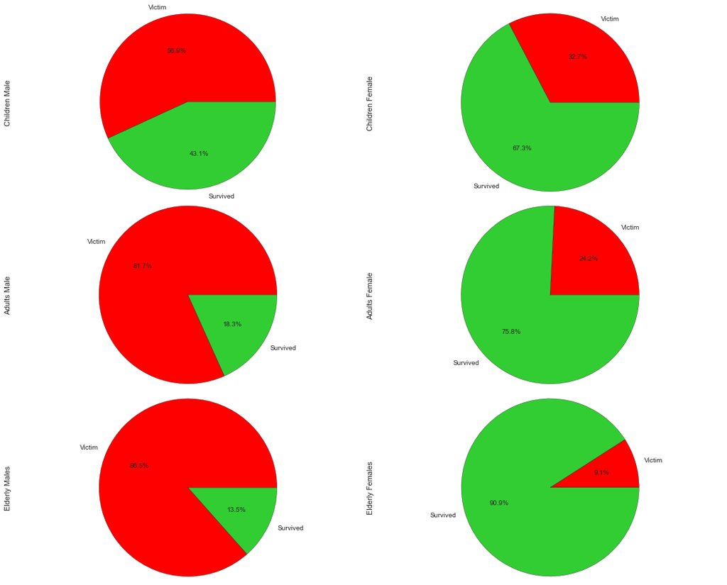

```python
#####################
#Children
children_male_passengers = children_passengers[ children_passengers['Sex'] == 'male' ]
children_female_passengers = children_passengers[ children_passengers['Sex'] == 'female' ]

children_male_by_survival = children_male_passengers.groupby('Survived')
children_male_survived = get_count(children_male_by_survival.get_group(1))
children_male_victim = get_count(children_male_by_survival.get_group(0))

children_female_by_survival = children_female_passengers.groupby('Survived')
children_female_survived = get_count(children_female_by_survival.get_group(1))
children_female_victim = get_count(children_female_by_survival.get_group(0))


#####################
#Adults
adults_male_passengers = adult_passengers[ adult_passengers['Sex'] == 'male' ]
adults_female_passengers = adult_passengers[ adult_passengers['Sex'] == 'female' ]

adults_male_by_survival = adults_male_passengers.groupby('Survived')
adults_male_survived = get_count(adults_male_by_survival.get_group(1))
adults_male_victim = get_count(adults_male_by_survival.get_group(0))

adults_female_by_survival = adults_female_passengers.groupby('Survived')
adults_female_survived = get_count(adults_female_by_survival.get_group(1))
adults_female_victim = get_count(adults_female_by_survival.get_group(0))

#####################
#Elderly
elderly_male_passengers = elderly_passengers[ elderly_passengers['Sex'] == 'male' ]
elderly_female_passengers = elderly_passengers[ elderly_passengers['Sex'] == 'female' ]

elderly_male_by_survival = elderly_male_passengers.groupby('Survived')
elderly_male_survived = get_count(elderly_male_by_survival.get_group(1))
elderly_male_victim = get_count(elderly_male_by_survival.get_group(0))

elderly_female_by_survival = elderly_female_passengers.groupby('Survived')
elderly_female_survived = get_count(elderly_female_by_survival.get_group(1))
elderly_female_victim = get_count(elderly_female_by_survival.get_group(0))



#Create the dataframe of Children, Adult, Elderly and Unspecified age's gender make up.
df = pd.DataFrame({'Male Children':   [children_male_survived, children_male_victim], \
                   'Female Children': [children_female_survived, children_female_victim],\
                   'Male Adults':     [adults_male_survived, adults_male_victim],\
                   'Female Adults':   [adults_female_survived, adults_female_victim],\
                   'Male Elderly':    [elderly_male_survived, elderly_male_victim],\
                   'Female Elderly':  [elderly_female_survived, elderly_female_victim] }, index = ["Survived", "Victim"])


#Display the dataframe as an HTML table
display_html(df)


#Start a multiplot plot
fig = plt.figure(figsize=(15,12))

#Children pie plot
## Male children
draw_pie_subplot( children_male_by_survival, 321, 'Children Male', 'SURVIVAL_GRAPH')
##Female Children
draw_pie_subplot( children_female_by_survival, 322, 'Children Female', 'SURVIVAL_GRAPH')


#Adults pie plot
##Male Adults
draw_pie_subplot( adults_male_by_survival, 323, 'Adults Male', 'SURVIVAL_GRAPH')
##Female Adults
draw_pie_subplot( adults_female_by_survival, 324, 'Adults Female', 'SURVIVAL_GRAPH')


#Elderly  pie plot
##Male Elderly
draw_pie_subplot( elderly_male_by_survival, 325, 'Elderly Males', 'SURVIVAL_GRAPH')
##Female Elderly
draw_pie_subplot( elderly_female_by_survival, 326, 'Elderly Females', 'SURVIVAL_GRAPH')

plt.tight_layout()
```

I find it interesting that even male children had a noticeably lower survival rate than female children.

## Exploring The Sample From The Class Point of View

### Population Pyramid of The Classes

[figure not shown]

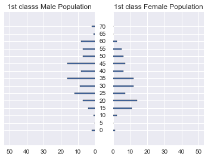

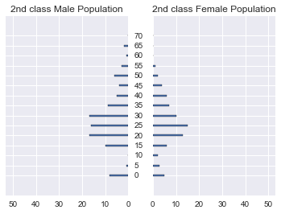

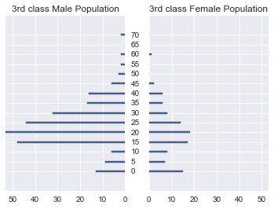

```python
#The code here follows the same logic for drawing the population pyramid for all the population above.
#But here, we are going to draw three graphs, one for each class
age_bins = range(0,75,5)

first_class_grouped_female_ages = get_count(first_class_female_passengers.groupby( pd.cut( first_class_female_passengers["Age"], np.arange(0, 80, 5) ) ))
first_class_grouped_male_ages =   get_count(first_class_male_passengers.groupby( pd.cut( first_class_male_passengers["Age"], np.arange(0, 80, 5) ) ))

second_class_grouped_female_ages = get_count(second_class_female_passengers.groupby( pd.cut( second_class_female_passengers["Age"], np.arange(0, 80, 5) ) ))
second_class_grouped_male_ages =   get_count(second_class_male_passengers.groupby( pd.cut( second_class_male_passengers["Age"], np.arange(0, 80, 5) ) ))

third_class_grouped_female_ages = get_count(third_class_female_passengers.groupby( pd.cut( third_class_female_passengers["Age"], np.arange(0, 80, 5) ) ))
third_class_grouped_male_ages =   get_count(third_class_male_passengers.groupby( pd.cut( third_class_male_passengers["Age"], np.arange(0, 80, 5) ) ))



fig = plt.figure(figsize=(7,7))

first_max_x = max(first_class_grouped_female_ages.max(), first_class_grouped_male_ages.max())
second_max_x = max(second_class_grouped_female_ages.max(), second_class_grouped_male_ages.max())
third_max_x = max(third_class_grouped_female_ages.max(), third_class_grouped_male_ages.max())

largest_x_value = max( [first_max_x, second_max_x, third_max_x] )

#Draw the population pyramid for the first class
fig.add_subplot(311)
plot_population_pyramid(age_bins, \
                        "1st classs Male Population", \
                        first_class_grouped_male_ages, \
                        "1st class Female Population", \
                        first_class_grouped_female_ages, \
                        largest_x_value)

#Draw the population pyramid for the second class
fig.add_subplot(312)
plot_population_pyramid(age_bins, \
                        "2nd class Male Population", \
                        second_class_grouped_male_ages, \
                        "2nd class Female Population", \
                        second_class_grouped_female_ages, \
                        largest_x_value)

#Draw the population pyramid for the third class
fig.add_subplot(313)
plot_population_pyramid(age_bins, \
                        "3rd class Male Population", \
                        third_class_grouped_male_ages, \
                        "3rd class Female Population", \
                        third_class_grouped_female_ages, \
                        largest_x_value)
```

- *I was not able to remove the first 3 emtpy plots, I think it is maybe a bug on PyPlot. More inverstigations will be needed.*

The third class' population pyramid is very skewed towards the male, with the largest spikes occur in between 15 to 30 years old.

### Classes, By Gender Ratio

|  | First Class | Second Class | Third Class |
| --- | --- | --- | --- |
| Male | 122 | 108 | 347 |
| Female | 94 | 76 | 144 |

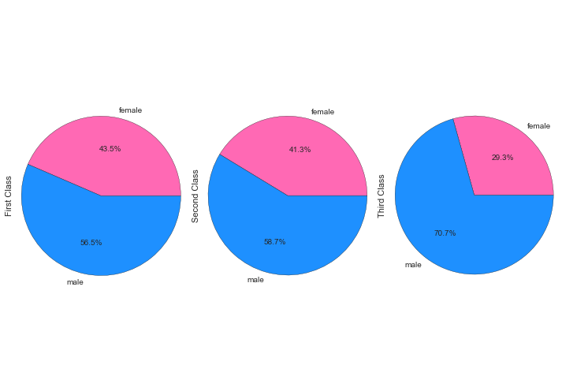

```python
#Create the dataframe of each class' gender make up.
df = pd.DataFrame({'First Class':  [first_class_male_count, first_class_female_count], \
                   'Second Class': [second_class_male_count, second_class_female_count],\
                   'Third Class':  [third_class_male_count, third_class_female_count]},\
                   index = ["Male", "Female"])


#Display the dataframe as an HTML table
display_html(df)


fig = plt.figure(figsize=(10,7))
#Plot the first class
draw_pie_subplot( first_class_passengers.groupby('Sex'), 131, 'First Class', 'GENDER_GRAPH')

#Plot the second class
draw_pie_subplot( second_class_passengers.groupby('Sex'), 132, 'Second Class', 'GENDER_GRAPH')

#Plot the third class
draw_pie_subplot( third_class_passengers.groupby('Sex'), 133, 'Third Class', 'GENDER_GRAPH')

plt.tight_layout()
```

### Classes, By Generation Make Up

[output not shown]

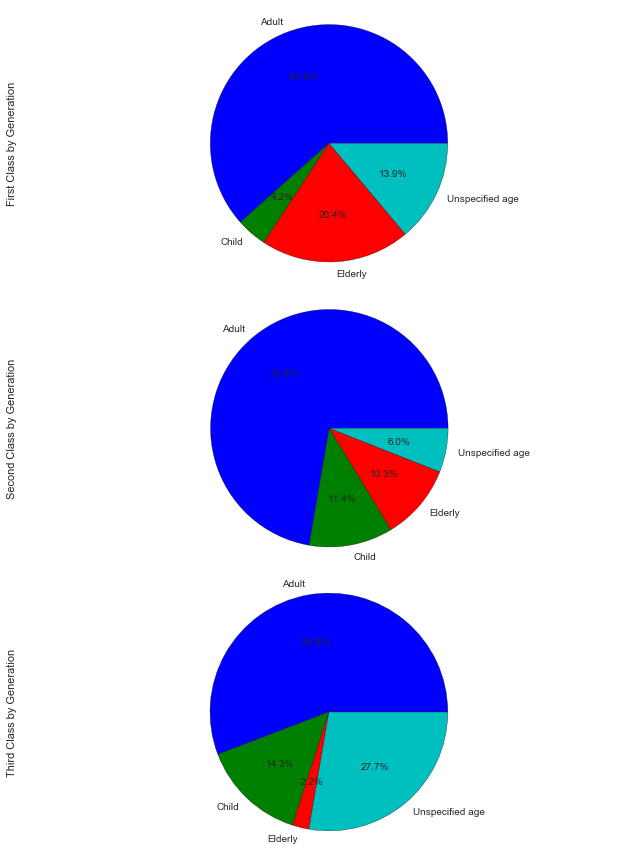

```python
first_class_unspecified_age = first_class_count - (first_class_children_count + first_class_adult_count + first_class_elderly_count)
second_class_unspecified_age = second_class_count - (second_class_children_count + second_class_adult_count + second_class_elderly_count)
third_class_unspecified_age = third_class_count - (third_class_children_count + third_class_adult_count + third_class_elderly_count)

#Create the dataframe of Children, Adult, Elderly and Unspecified age's gender make up, by class.
df = pd.DataFrame({'Children':       [first_class_children_count, second_class_children_count, third_class_children_count], \
                   'Adults':         [first_class_adult_count, second_class_adult_count, third_class_adult_count],\
                   'Elderly':        [first_class_elderly_count, second_class_elderly_count, third_class_elderly_count],\
                   'Unspecified Age':[first_class_unspecified_age, second_class_unspecified_age, third_class_unspecified_age]},\
                   index = ["First Class", "Second Class", "Third Class"])


#Display the dataframe as an HTML table
display_html(df)


fig = plt.figure(figsize=(9,12))

#First Class
draw_pie_subplot(first_class_passengers.groupby('Generation'), 311, 'First Class by Generation', 'DEFAULT')

#Second Class
draw_pie_subplot(second_class_passengers.groupby('Generation'), 312, 'Second Class by Generation', 'DEFAULT')

#Third Class
draw_pie_subplot(third_class_passengers.groupby('Generation'), 313, 'Third Class by Generation', 'DEFAULT')


plt.tight_layout()
```

It might be worth noting that the majority of the passengers of unspecified age come from the third class.

### Class Survival

|  | Died | Survived |
| --- | --- | --- |
| First Class | 80 | 136 |
| Second Class | 97 | 87 |
| Third Class | 372 | 119 |

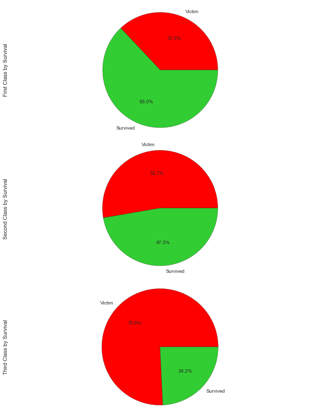

```python
#Separate each class passengers by survival
first_class_by_survival = first_class_passengers.groupby("Survived")
second_class_by_survival = second_class_passengers.groupby("Survived")
third_class_by_survival = third_class_passengers.groupby("Survived")

#Get the count of both survivors and victims, by each class
first_class_surviving_count = get_count(first_class_by_survival.get_group(1))
first_class_victims_count = get_count(first_class_by_survival.get_group(0))

second_class_surviving_count = get_count(second_class_by_survival.get_group(1))
second_class_victims_count = get_count(second_class_by_survival.get_group(0))

third_class_surviving_count = get_count(third_class_by_survival.get_group(1))
third_class_victims_count = get_count(third_class_by_survival.get_group(0))


#Create the dataframe of Children, Adult, Elderly and Unspecified age's gender make up, by class.
df = pd.DataFrame({'Survived': [first_class_surviving_count, second_class_surviving_count, third_class_surviving_count], \
                   'Died':     [first_class_victims_count, second_class_victims_count, third_class_victims_count]},\
                   index = ["First Class", "Second Class", "Third Class"])

#Display the dataframe as an HTML table
display_html(df)


fig = plt.figure(figsize=(9,12))

#First Class
draw_pie_subplot( first_class_passengers.groupby('Survived'), 311, 'First Class by Survival', 'SURVIVAL_GRAPH')

#Second Class
draw_pie_subplot( second_class_passengers.groupby('Survived') , 312, 'Second Class by Survival', 'SURVIVAL_GRAPH')

#Third Class
draw_pie_subplot( third_class_passengers.groupby('Survived') , 313, 'Third Class by Survival', 'SURVIVAL_GRAPH')

plt.tight_layout()
```

Just visually, one can see that the better the class was, the higher the chances of survival were. But this is just superficially, from the pie charts. Other factors may be involved as well, like the total number of passengers and the gender makeup of each class (The percentage of males in the third class was much higher than the other two classes).

### Survival: From The Point of View of The Generation And Gender

#### Class' Children Survival, Broken down By Both The Total And The Gender

|  | Died | Survived |
| --- | --- | --- |
| First Class | 1 | 8 |
| Second Class | 2 | 19 |
| Third Class | 42 | 28 |

|  | First Class | Second Class | Third Class |
| --- | --- | --- | --- |
| Male Survivor | 3 | 9 | 10 |
| Male Victim | 0 | 2 | 27 |
| Female Survivor | 5 | 10 | 18 |
| Female Victim | 1 | 0 | 15 |

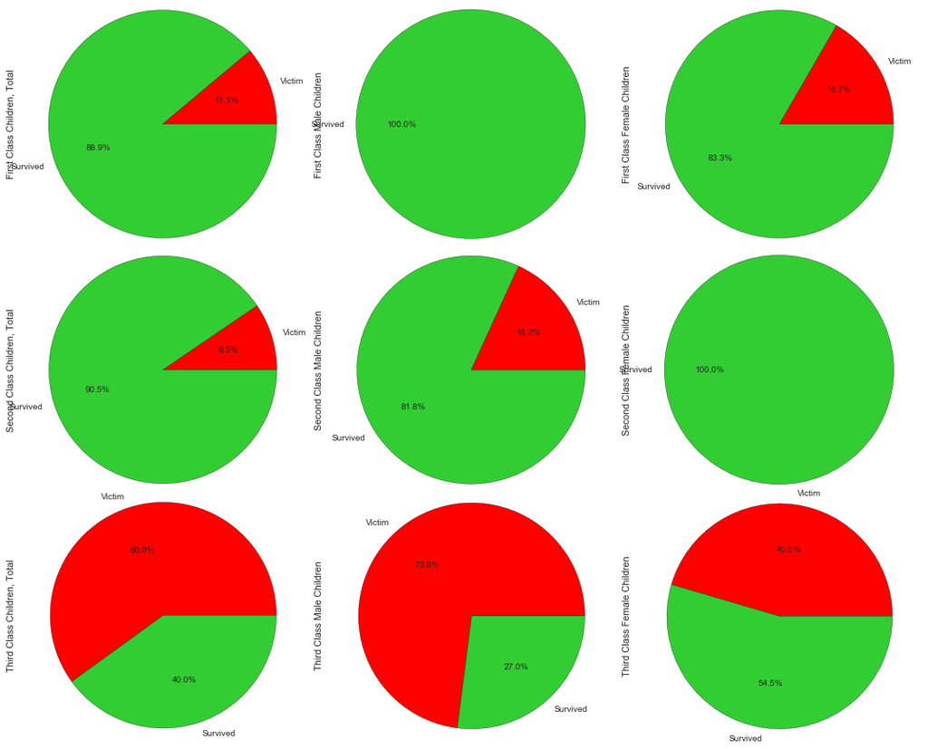

```python
#First, group each class by generation survival, AND by (generation and gender)'s survival
#####First Class
first_class_children_by_survival = first_class_children_passengers.groupby("Survived")
first_class_children_male_by_survival = first_class_children_male_passengers.groupby("Survived")
first_class_children_female_by_survival = first_class_children_female_passengers.groupby("Survived")

#####Second Class
second_class_children_by_survival = second_class_children_passengers.groupby("Survived")
second_class_children_male_by_survival = second_class_children_male_passengers.groupby("Survived")
second_class_children_female_by_survival = second_class_children_female_passengers.groupby("Survived")

#####Third Class
third_class_children_by_survival = third_class_children_passengers.groupby("Survived")
third_class_children_male_by_survival = third_class_children_male_passengers.groupby("Survived")
third_class_children_female_by_survival = third_class_children_female_passengers.groupby("Survived")

#Get the count of each category created in the cell above
first_class_children_surviving_count = get_surviving_count( first_class_children_by_survival)
first_class_children_victims_count = get_victim_count(first_class_children_by_survival)
first_class_children_male_surviving_count = get_surviving_count( first_class_children_male_by_survival)
first_class_children_male_victims_count = get_victim_count(first_class_children_male_by_survival)
first_class_children_female_surviving_count = get_surviving_count(first_class_children_female_by_survival)
first_class_children_female_victims_count = get_victim_count(first_class_children_female_by_survival)

second_class_children_surviving_count = get_surviving_count( second_class_children_by_survival)
second_class_children_victims_count = get_victim_count(second_class_children_by_survival)
second_class_children_male_surviving_count = get_surviving_count( second_class_children_male_by_survival)
second_class_children_male_victims_count = get_victim_count(second_class_children_male_by_survival)
second_class_children_female_surviving_count = get_surviving_count(second_class_children_female_by_survival)
second_class_children_female_victims_count = get_victim_count(second_class_children_female_by_survival)

third_class_children_surviving_count = get_surviving_count( third_class_children_by_survival)
third_class_children_victims_count = get_victim_count(third_class_children_by_survival)
third_class_children_male_surviving_count = get_surviving_count( third_class_children_male_by_survival)
third_class_children_male_victims_count = get_victim_count(third_class_children_male_by_survival)
third_class_children_female_surviving_count = get_surviving_count(third_class_children_female_by_survival)
third_class_children_female_victims_count = get_victim_count(third_class_children_female_by_survival)

#Create the dataframe of the classes' children by survival
df = pd.DataFrame({'Survived': [first_class_children_surviving_count, second_class_children_surviving_count, third_class_children_surviving_count], \
                   'Died':     [first_class_children_victims_count, second_class_children_victims_count, third_class_children_victims_count]},\
                   index = ["First Class", "Second Class", "Third Class"])

#Display the dataframe as an HTML table
display_html(df)

#Create the dataframe of the classes' children by survival
df = pd.DataFrame({'First Class':  [first_class_children_male_surviving_count, \
                                    first_class_children_male_victims_count, \
                                    first_class_children_female_surviving_count, \
                                    first_class_children_female_victims_count], \

                   'Second Class': [second_class_children_male_surviving_count, \
                                    second_class_children_male_victims_count, \
                                    second_class_children_female_surviving_count, \
                                    second_class_children_female_victims_count],\

                   'Third Class':  [third_class_children_male_surviving_count, \
                                    third_class_children_male_victims_count, \
                                    third_class_children_female_surviving_count, \
                                    third_class_children_female_victims_count]},\

                   index = ["Male Survivor", "Male Victim", "Female Survivor", "Female Victim"] )

#Display the dataframe as an HTML table
display_html(df)


fig = plt.figure(figsize=(15,12))

#First Class
draw_pie_subplot( first_class_children_by_survival , 331, 'First Class Children, Total', 'SURVIVAL_GRAPH')
draw_pie_subplot( first_class_children_male_by_survival , 332, 'First Class Male Children', 'SURVIVAL_GRAPH')
draw_pie_subplot( first_class_children_female_by_survival , 333, 'First Class Female Children', 'SURVIVAL_GRAPH')

#Second Class
draw_pie_subplot( second_class_children_by_survival , 334, 'Second Class Children, Total', 'SURVIVAL_GRAPH')
draw_pie_subplot( second_class_children_male_by_survival , 335, 'Second Class Male Children', 'SURVIVAL_GRAPH')
draw_pie_subplot( second_class_children_female_by_survival , 336, 'Second Class Female Children', 'SURVIVAL_GRAPH')

#Third Class
draw_pie_subplot( third_class_children_by_survival , 337, 'Third Class Children, Total', 'SURVIVAL_GRAPH')
draw_pie_subplot( third_class_children_male_by_survival , 338, 'Third Class Male Children', 'SURVIVAL_GRAPH')
draw_pie_subplot( third_class_children_female_by_survival , 339, 'Third Class Female Children', 'SURVIVAL_GRAPH')
plt.tight_layout()
```

#### Total Children Survival, By Class

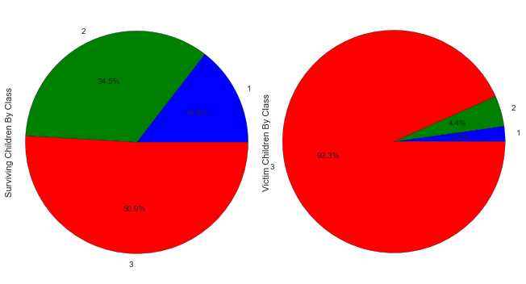

```python
children_by_class = children_passengers.groupby('Pclass')

children_survived_by_class = children_by_class.apply(lambda t : t[t['Survived'] == 1]).groupby('Pclass')
children_drowned_by_class = children_by_class.apply(lambda t : t[t['Survived'] == 0]).groupby('Pclass')

fig = plt.figure(figsize=(9,5))

draw_pie_subplot( children_survived_by_class, 121, 'Surviving Children By Class', 'DEFAULT')

draw_pie_subplot( children_drowned_by_class, 122, 'Victim Children By Class', 'DEFAULT')

plt.tight_layout()
```

|  | Died | Survived |
| --- | --- | --- |
| First Class | 39 | 94 |
| Second Class | 75 | 58 |
| Third Class | 218 | 56 |

|  | First Class | Second Class | Third Class |
| --- | --- | --- | --- |
| Male Survivor | 31 | 5 | 28 |
| Male Victim | 38 | 70 | 178 |
| Female Survivor | 63 | 53 | 28 |
| Female Victim | 1 | 5 | 40 |

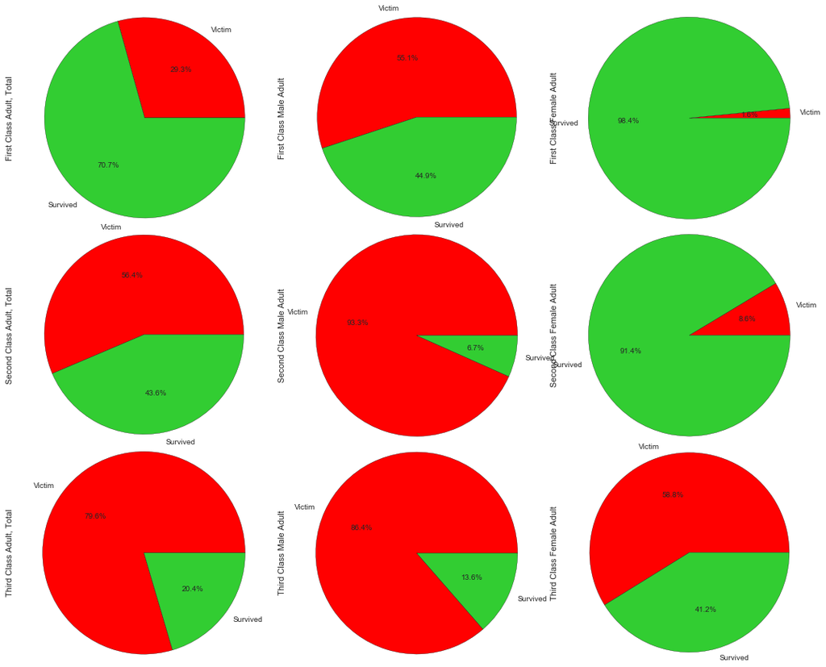

```python
#First, group each class by generation survival, AND by (generation and gender)'s survival
#####First Class
first_class_adult_by_survival = first_class_adult_passengers.groupby("Survived")
first_class_adult_male_by_survival = first_class_adult_male_passengers.groupby("Survived")
first_class_adult_female_by_survival = first_class_adult_female_passengers.groupby("Survived")

#####Second Class
second_class_adult_by_survival = second_class_adult_passengers.groupby("Survived")
second_class_adult_male_by_survival = second_class_adult_male_passengers.groupby("Survived")
second_class_adult_female_by_survival = second_class_adult_female_passengers.groupby("Survived")

#####Third Class
third_class_adult_by_survival = third_class_adult_passengers.groupby("Survived")
third_class_adult_male_by_survival = third_class_adult_male_passengers.groupby("Survived")
third_class_adult_female_by_survival = third_class_adult_female_passengers.groupby("Survived")

#Get the count of each category created in the cell above
first_class_adult_surviving_count = get_surviving_count( first_class_adult_by_survival)
first_class_adult_victims_count = get_victim_count(first_class_adult_by_survival)
first_class_adult_male_surviving_count = get_surviving_count( first_class_adult_male_by_survival)
first_class_adult_male_victims_count = get_victim_count(first_class_adult_male_by_survival)
first_class_adult_female_surviving_count = get_surviving_count(first_class_adult_female_by_survival)
first_class_adult_female_victims_count = get_victim_count(first_class_adult_female_by_survival)

second_class_adult_surviving_count = get_surviving_count( second_class_adult_by_survival)
second_class_adult_victims_count = get_victim_count(second_class_adult_by_survival)
second_class_adult_male_surviving_count = get_surviving_count( second_class_adult_male_by_survival)
second_class_adult_male_victims_count = get_victim_count(second_class_adult_male_by_survival)
second_class_adult_female_surviving_count = get_surviving_count(second_class_adult_female_by_survival)
second_class_adult_female_victims_count = get_victim_count(second_class_adult_female_by_survival)

third_class_adult_surviving_count = get_surviving_count( third_class_adult_by_survival)
third_class_adult_victims_count = get_victim_count(third_class_adult_by_survival)
third_class_adult_male_surviving_count = get_surviving_count( third_class_adult_male_by_survival)
third_class_adult_male_victims_count = get_victim_count(third_class_adult_male_by_survival)
third_class_adult_female_surviving_count = get_surviving_count(third_class_adult_female_by_survival)
third_class_adult_female_victims_count = get_victim_count(third_class_adult_female_by_survival)

#Create the dataframe of the classes' adult by survival
df = pd.DataFrame({'Survived': [first_class_adult_surviving_count, second_class_adult_surviving_count, third_class_adult_surviving_count], \
                   'Died':     [first_class_adult_victims_count, second_class_adult_victims_count, third_class_adult_victims_count]},\
                   index = ["First Class", "Second Class", "Third Class"])

#Display the dataframe as an HTML table
display_html(df)

#Create the dataframe of the classes' adult by survival
df = pd.DataFrame({'First Class':  [first_class_adult_male_surviving_count, \
                                    first_class_adult_male_victims_count, \
                                    first_class_adult_female_surviving_count, \
                                    first_class_adult_female_victims_count], \

                   'Second Class': [second_class_adult_male_surviving_count, \
                                    second_class_adult_male_victims_count, \
                                    second_class_adult_female_surviving_count, \
                                    second_class_adult_female_victims_count],\

                   'Third Class':  [third_class_adult_male_surviving_count, \
                                    third_class_adult_male_victims_count, \
                                    third_class_adult_female_surviving_count, \
                                    third_class_adult_female_victims_count]},\
                   index = ["Male Survivor", "Male Victim", "Female Survivor", "Female Victim"] )

#Display the dataframe as an HTML table
display_html(df)


fig = plt.figure(figsize=(15,12))

#First Class
draw_pie_subplot( first_class_adult_by_survival , 331, 'First Class Adult, Total', 'SURVIVAL_GRAPH')
draw_pie_subplot( first_class_adult_male_by_survival , 332, 'First Class Male Adult', 'SURVIVAL_GRAPH')
draw_pie_subplot( first_class_adult_female_by_survival , 333, 'First Class Female Adult', 'SURVIVAL_GRAPH')

#Second Class
draw_pie_subplot( second_class_adult_by_survival , 334, 'Second Class Adult, Total', 'SURVIVAL_GRAPH')
draw_pie_subplot( second_class_adult_male_by_survival , 335, 'Second Class Male Adult', 'SURVIVAL_GRAPH')
draw_pie_subplot( second_class_adult_female_by_survival , 336, 'Second Class Female Adult', 'SURVIVAL_GRAPH')

#Third Class
draw_pie_subplot( third_class_adult_by_survival , 337, 'Third Class Adult, Total', 'SURVIVAL_GRAPH')
draw_pie_subplot( third_class_adult_male_by_survival , 338, 'Third Class Male Adult', 'SURVIVAL_GRAPH')
draw_pie_subplot( third_class_adult_female_by_survival , 339, 'Third Class Female Adult', 'SURVIVAL_GRAPH')

plt.tight_layout()
```

Second Class males, to my surprise, had the toughest luck. I was expecting the third class males to have the toughest one.

#### Total Adults Survival, By Class

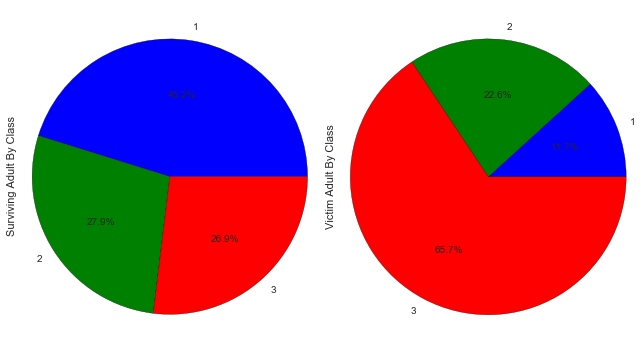

```python
adult_by_class = adult_passengers.groupby('Pclass')

adult_survived_by_class = adult_by_class.apply(lambda t : t[t['Survived'] == 1]).groupby('Pclass')
adult_drowned_by_class = adult_by_class.apply(lambda t : t[t['Survived'] == 0]).groupby('Pclass')

fig = plt.figure(figsize=(9,5))

draw_pie_subplot( adult_survived_by_class, 121, 'Surviving Adult By Class', 'DEFAULT')

draw_pie_subplot( adult_drowned_by_class, 122, 'Victim Adult By Class', 'DEFAULT')

plt.tight_layout()
```

#### Class' Elderly Survival, Broken Down By Both The Total And The Gender

[output not shown]

[output not shown]

[figure not shown]

```python
#First, group each class by generation survival, AND by (generation and gender)'s survival
#####First Class
first_class_elderly_by_survival = first_class_elderly_passengers.groupby("Survived")
first_class_elderly_male_by_survival = first_class_elderly_male_passengers.groupby("Survived")
first_class_elderly_female_by_survival = first_class_elderly_female_passengers.groupby("Survived")

#####Second Class
second_class_elderly_by_survival = second_class_elderly_passengers.groupby("Survived")
second_class_elderly_male_by_survival = second_class_elderly_male_passengers.groupby("Survived")
second_class_elderly_female_by_survival = second_class_elderly_female_passengers.groupby("Survived")

#####Third Class
third_class_elderly_by_survival = third_class_elderly_passengers.groupby("Survived")
third_class_elderly_male_by_survival = third_class_elderly_male_passengers.groupby("Survived")
third_class_elderly_female_by_survival = third_class_elderly_female_passengers.groupby("Survived")

#Get the count of each category created in the cell above
first_class_elderly_surviving_count = get_surviving_count( first_class_elderly_by_survival)
first_class_elderly_victims_count = get_victim_count(first_class_elderly_by_survival)
first_class_elderly_male_surviving_count = get_surviving_count( first_class_elderly_male_by_survival)
first_class_elderly_male_victims_count = get_victim_count(first_class_elderly_male_by_survival)
first_class_elderly_female_surviving_count = get_surviving_count(first_class_elderly_female_by_survival)
first_class_elderly_female_victims_count = get_victim_count(first_class_elderly_female_by_survival)

second_class_elderly_surviving_count = get_surviving_count( second_class_elderly_by_survival)
second_class_elderly_victims_count = get_victim_count(second_class_elderly_by_survival)
second_class_elderly_male_surviving_count = get_surviving_count( second_class_elderly_male_by_survival)
second_class_elderly_male_victims_count = get_victim_count(second_class_elderly_male_by_survival)
second_class_elderly_female_surviving_count = get_surviving_count(second_class_elderly_female_by_survival)
second_class_elderly_female_victims_count = get_victim_count(second_class_elderly_female_by_survival)

third_class_elderly_surviving_count = get_surviving_count( third_class_elderly_by_survival)
third_class_elderly_victims_count = get_victim_count(third_class_elderly_by_survival)
third_class_elderly_male_surviving_count = get_surviving_count( third_class_elderly_male_by_survival)
third_class_elderly_male_victims_count = get_victim_count(third_class_elderly_male_by_survival)
third_class_elderly_female_surviving_count = get_surviving_count(third_class_elderly_female_by_survival)
third_class_elderly_female_victims_count = get_victim_count(third_class_elderly_female_by_survival)

#Create the dataframe of the classes' elderly by survival
df = pd.DataFrame({'Survived': [first_class_elderly_surviving_count, second_class_elderly_surviving_count, third_class_elderly_surviving_count], \
                   'Died':     [first_class_elderly_victims_count, second_class_elderly_victims_count, third_class_elderly_victims_count]},\
                   index = ["First Class", "Second Class", "Third Class"])

#Display the dataframe as an HTML table
display_html(df)

#Create the dataframe of the classes' elderly by survival
df = pd.DataFrame({'First Class':  [first_class_elderly_male_surviving_count, \
                                    first_class_elderly_male_victims_count, \
                                    first_class_elderly_female_surviving_count, \
                                    first_class_elderly_female_victims_count], \

                   'Second Class': [second_class_elderly_male_surviving_count, \
                                    second_class_elderly_male_victims_count, \
                                    second_class_elderly_female_surviving_count, \
                                    second_class_elderly_female_victims_count],\

                   'Third Class':  [third_class_elderly_male_surviving_count, \
                                    third_class_elderly_male_victims_count, \
                                    third_class_elderly_female_surviving_count, \
                                    third_class_elderly_female_victims_count]},\
                   index = ["Male Survivor", "Male Victim", "Female Survivor", "Female Victim"] )

#Display the dataframe as an HTML table
display_html(df)


fig = plt.figure(figsize=(15,12))
#First Class
draw_pie_subplot( first_class_elderly_by_survival , 331, 'First Class Elderly, Total', 'SURVIVAL_GRAPH')
draw_pie_subplot( first_class_elderly_male_by_survival , 332, 'First Class Male Elderly', 'SURVIVAL_GRAPH')
draw_pie_subplot( first_class_elderly_female_by_survival , 333, 'First Class Female Elderly', 'SURVIVAL_GRAPH')

#Second Class
draw_pie_subplot( second_class_elderly_by_survival , 334, 'Second Class Elderly, Total', 'SURVIVAL_GRAPH')
draw_pie_subplot( second_class_elderly_male_by_survival , 335, 'Second Class Male Elderly', 'SURVIVAL_GRAPH')
draw_pie_subplot( second_class_elderly_female_by_survival , 336, 'Second Class Female Elderly', 'SURVIVAL_GRAPH')

#Third Class
draw_pie_subplot( third_class_elderly_by_survival , 337, 'Third Class Elderly, Total', 'SURVIVAL_GRAPH')
draw_pie_subplot( third_class_elderly_male_by_survival , 338, 'Third Class Male Elderly', 'SURVIVAL_GRAPH')
draw_pie_subplot( third_class_elderly_female_by_survival , 339, 'Third Class Female Elderly', 'SURVIVAL_GRAPH')

plt.tight_layout()
```

#### Total Elderly Survival, By Class

[figure not shown]

```python
elderly_by_class = elderly_passengers.groupby('Pclass')

elderly_survived_by_class = elderly_by_class.apply(lambda t : t[t['Survived'] == 1]).groupby('Pclass')
elderly_drowned_by_class = elderly_by_class.apply(lambda t : t[t['Survived'] == 0]).groupby('Pclass')

fig = plt.figure(figsize=(9,5))

draw_pie_subplot( elderly_survived_by_class, 121, 'Victim Elderly By Class', 'DEFAULT')

draw_pie_subplot( elderly_drowned_by_class, 122, 'Victim Elderly By Class', 'DEFAULT')

plt.tight_layout()
```

## Survival

Because of the tragedy, I feel that we should look again in the survival of the individual. Some of the data that will be presented here can be redundunt with what have been presented above, already. But I think we should still re-examine the survival from angles.

### Survivors vs Victims age Pyramid

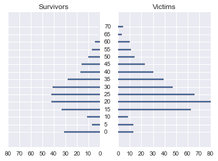

```python
age_bins = range(0,75,5)

survivors_ages = get_count(surviving_passengers.groupby( pd.cut( surviving_passengers["Age"], np.arange(0, 80, 5) ) ))
victims_ages = get_count(victim_passengers.groupby( pd.cut( victim_passengers["Age"], np.arange(0, 80, 5) ) ))

largest_x_value = max(survivors_ages.max(), victims_ages.max() )

plot_population_pyramid(age_bins, "Survivors", survivors_ages, "Victims", victims_ages, largest_x_value)
```

### Male Survivors vs Male Victims Age Pyramid

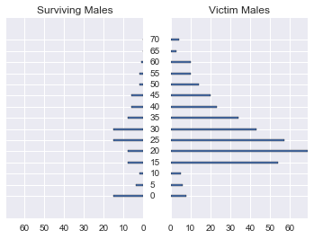

```python
surviving_males = surviving_passengers[ surviving_passengers['Sex'] == 'male']
victim_males = victim_passengers[ victim_passengers['Sex'] == 'male']

age_bins = range(0,75,5)

surviving_males_ages = get_count(surviving_males.groupby( pd.cut( surviving_males["Age"], np.arange(0, 80, 5) ) ))
victim_males_ages = get_count(victim_males.groupby( pd.cut( victim_males["Age"], np.arange(0, 80, 5) ) ))

largest_x_value = max(surviving_males_ages.max(), victim_males_ages.max() )

plot_population_pyramid(age_bins, "Surviving Males", surviving_males_ages, "Victim Males", victim_males_ages, largest_x_value)
```

### Female Survivors vs Female Victims Age Pyramid

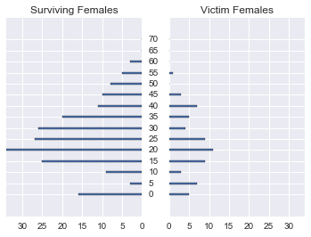

```python
surviving_females = surviving_passengers[ surviving_passengers['Sex'] == 'female']
victim_females = victim_passengers[ victim_passengers['Sex'] == 'female']

age_bins = range(0,75,5)

surviving_females_ages = get_count(surviving_females.groupby( pd.cut( surviving_females["Age"], np.arange(0, 80, 5) ) ))
victim_females_ages = get_count(victim_females.groupby( pd.cut( victim_females["Age"], np.arange(0, 80, 5) ) ))

largest_x_value = max(surviving_females_ages.max(), victim_females_ages.max() )

plot_population_pyramid(age_bins, \
                        "Surviving Females", \
                        surviving_females_ages, \
                        "Victim Females", \
                        victim_females_ages, \
                        largest_x_value)
```

### How Were The Boats Divided Among Different Classes ?

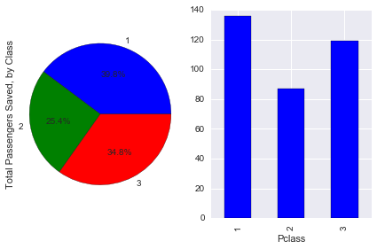

```python
fig = plt.figure()


fig.add_subplot(121)
titanic_all_data['Survived'].groupby(titanic_all_data['Pclass']).sum().plot.pie(label = 'Total Passengers Saved, by Class', \
                                                                                autopct='%1.1f%%')
plt.axis('equal')

fig.add_subplot(122)
titanic_all_data['Survived'].groupby(titanic_all_data['Pclass']).sum().plot.bar(label = 'Total Passengers Saved, by Class')

plt.tight_layout()
```

It looks much more fair than what I have expected. Of course one can argue here that, the majority of women and children of the upper classes were already saved, and this is why the pie chart looks evenly distributed; but I would still say that it is not as bad as I thought before I have plot these graphs.

### Survivors, By Generation, General

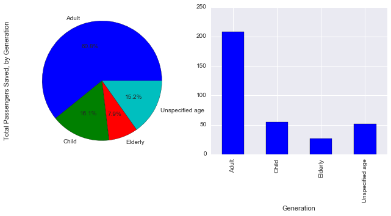

```python
fig = plt.figure(figsize=(9,5))


fig.add_subplot(121)
titanic_all_data['Survived'].groupby(titanic_all_data['Generation']).sum().plot.pie(label = 'Total Passengers Saved, by Generation',\
                                                                                    autopct='%1.1f%%')
plt.axis('equal')

fig.add_subplot(122)
titanic_all_data['Survived'].groupby(titanic_all_data['Generation']).sum().plot.bar(label = 'Total Passengers Saved, by Generation')

plt.tight_layout()
```

### Victims, By Generation, General

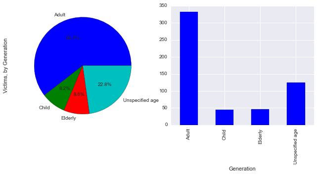

```python
fig = plt.figure(figsize=(9,5))

fig.add_subplot(121)
victim_passengers['Survived'].groupby(victim_passengers['Generation']).count().plot.pie(label = 'Victims, by Generation', \
                                                                                        autopct='%1.1f%%')
plt.axis('equal')

fig.add_subplot(122)
victim_passengers['Survived'].groupby(victim_passengers['Generation']).count().plot.bar(label = 'Victims, by Generation')

plt.tight_layout()
```

### Survivors, By Generation and Class

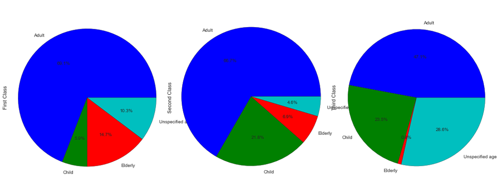

```python
fig = plt.figure(figsize=(15,6))

fig.add_subplot(131)
#First class plot
first_class_survivors['Survived'].groupby(first_class_survivors['Generation']).count().plot.pie(label = 'First Class', \
                                                                                                autopct='%1.1f%%')
plt.axis('equal')

fig.add_subplot(132)
#Second class plot
second_class_survivors['Survived'].groupby(second_class_survivors['Generation']).count().plot.pie(label = 'Second Class', \
                                                                                                  autopct='%1.1f%%')
plt.axis('equal')

fig.add_subplot(133)
#Third class plot
third_class_survivors['Survived'].groupby(third_class_survivors['Generation']).count().plot.pie(label = 'Third Class', \
                                                                                                autopct='%1.1f%%')
plt.axis('equal')

plt.tight_layout()
```

### Victims, By Generation and Class

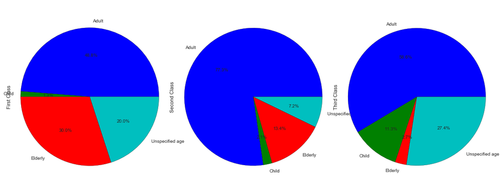

```python
fig = plt.figure(figsize=(15,6))

fig.add_subplot(131)
#First class plot
first_class_victims['Survived'].groupby(first_class_victims['Generation']).count().plot.pie(label = 'First Class', \
                                                                                            autopct='%1.1f%%')
plt.axis('equal')

fig.add_subplot(132)
#Second class plot
second_class_victims['Survived'].groupby(second_class_victims['Generation']).count().plot.pie(label = 'Second Class', \
                                                                                              autopct='%1.1f%%')
plt.axis('equal')

fig.add_subplot(133)
#Third class plot
third_class_victims['Survived'].groupby(third_class_victims['Generation']).count().plot.pie(label = 'Third Class', \
                                                                                            autopct='%1.1f%%')
plt.axis('equal')

plt.tight_layout()
```

## Travel Companionship

Now, after gaining some intuition about the data, one final parameter is left to explore so we can start answering our first question: companionship.

### Solo Travelers vs Group Travelers, Total

|  | Count |
| --- | --- |
| Solo | 521 |
| Group | 370 |

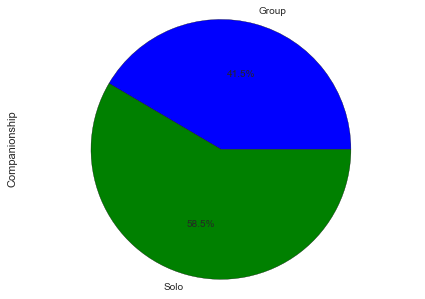

```python
solo_passengers_count =  get_count(passengers_by_companionship.get_group(True))
group_passengers_count = get_count(passengers_by_companionship.get_group(False))


df = pd.DataFrame({'Count': [solo_passengers_count, group_passengers_count]}, index = ['Solo', 'Group'])

display_html(df)

get_count(titanic_all_data.groupby('isSolo')).plot.pie(labels=['Group', 'Solo'], \
                                                                   label = "Companionship", \
                                                                   autopct='%1.1f%%')
plt.axis('equal')

plt.tight_layout()
```

### Travel Companionship, by Class Make Up

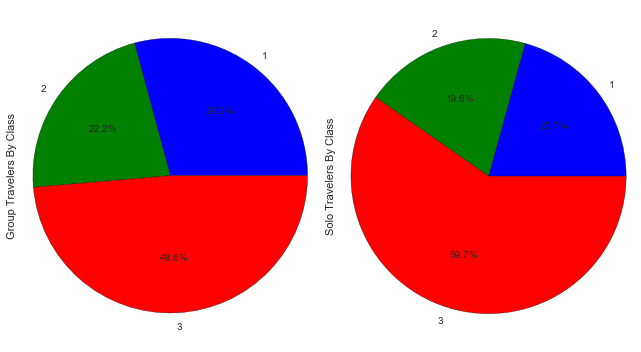

```python
group_travelers_by_class = passengers_by_class.apply(lambda t : t[t['isSolo'] == False]).groupby('Pclass')
solo_travelers_by_class = passengers_by_class.apply(lambda t : t[t['isSolo'] == True]).groupby('Pclass')


fig = plt.figure(figsize=(9,5))

draw_pie_subplot( group_travelers_by_class, 121, 'Group Travelers By Class', 'DEFAULT')
draw_pie_subplot( solo_travelers_by_class, 122, 'Solo Travelers By Class', 'DEFAULT')

plt.tight_layout()
```

### Solo Travelers vs Group Travelers, By Class

[output not shown]

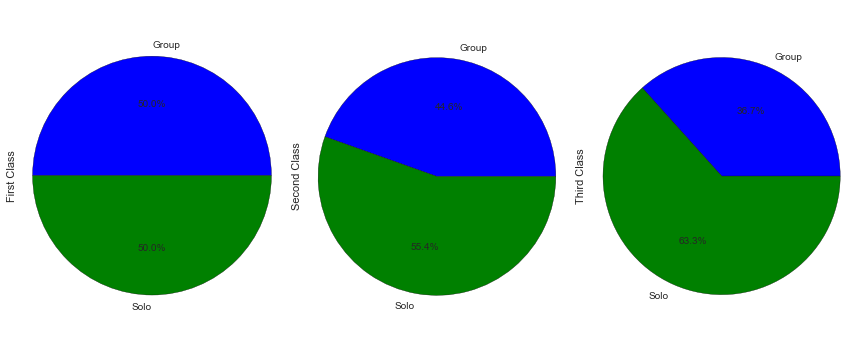

```python
solo_passengers_count =  get_count(passengers_by_companionship.get_group(True))
group_passengers_count = get_count(passengers_by_companionship.get_group(False))

first_class_solo_passengers_count =  get_count(first_class_passengers[ first_class_passengers['isSolo'] == True])
first_class_group_passengers_count =  get_count(first_class_passengers[ first_class_passengers['isSolo'] == False])

second_class_solo_passengers_count =  get_count(second_class_passengers[ second_class_passengers['isSolo'] == True])
second_class_group_passengers_count =  get_count(second_class_passengers[ second_class_passengers['isSolo'] == False])

third_class_solo_passengers_count =  get_count(third_class_passengers[ third_class_passengers['isSolo'] == True])
third_class_group_passengers_count =  get_count(third_class_passengers[ third_class_passengers['isSolo'] == False])

df = pd.DataFrame({'First Class':  [first_class_solo_passengers_count, first_class_group_passengers_count], \
                   'Second Class': [second_class_solo_passengers_count, second_class_group_passengers_count], \
                   'Third Class':  [third_class_solo_passengers_count, third_class_group_passengers_count]}, \
                  index = ['Group', 'Solo'])

display_html(df)

fig = plt.figure(figsize=(12,5))

fig.add_subplot(131)
get_count(first_class_passengers.groupby('isSolo')).plot.pie(label = 'First Class', \
                                                                         labels=['Group', 'Solo'],\
                                                                         autopct='%1.1f%%')
plt.axis('equal')

fig.add_subplot(132)
get_count(second_class_passengers.groupby('isSolo')).plot.pie(label = 'Second Class', \
                                                                         labels=['Group', 'Solo'],\
                                                                          autopct='%1.1f%%')
plt.axis('equal')

fig.add_subplot(133)
get_count(third_class_passengers.groupby('isSolo')).plot.pie(label = 'Third Class', \
                                                                         labels=['Group', 'Solo'],\
                                                                         autopct='%1.1f%%')
plt.axis('equal')

plt.tight_layout()
```

### Solo Travelers Age Pyramid

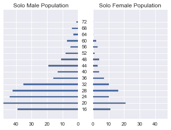

```python
age_bins = range(16,76,4)

solo_female_passengers = female_passengers[ female_passengers['isSolo'] == True ]
solo_male_passengers = male_passengers[ male_passengers['isSolo'] == True ]

grouped_female_ages = get_count(solo_female_passengers.groupby( pd.cut( solo_female_passengers["Age"], np.arange(16, 80, 4) ) ))
grouped_male_ages =   get_count(solo_male_passengers.groupby( pd.cut( solo_male_passengers["Age"], np.arange(16, 80, 4) ) ))

largest_x_value = max(grouped_female_ages.max(), grouped_male_ages.max())

plot_population_pyramid(age_bins, \
                        "Solo Male Population", \
                        grouped_male_ages, \
                        "Solo Female Population", \
                        grouped_female_ages, \
                        largest_x_value)
```

### Women Traveling Companionship Pattern

I got curious about solo women traveling on the ship, since the accident happened during a time when the culture was more conservative than nowadays.

```
Women traveling alone:      118  Percentage: 37.58%
Women traveling in a group: 196  Percentage: 62.42%
```

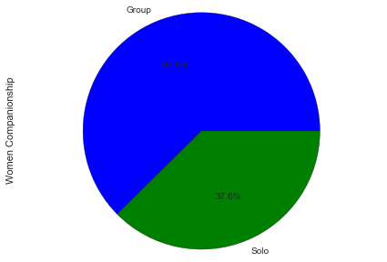

```python
get_count(passengers_by_gender.get_group('female').groupby('isSolo')).plot.pie(labels=['Group', 'Solo'], \
                                                                                           label = " Women Companionship", \
                                                                                           autopct='%1.1f%%')
plt.axis('equal')

plt.tight_layout()

group_women_count = get_count(passengers_by_gender.get_group('female').groupby('isSolo'))[0]
solo_women_count = get_count(passengers_by_gender.get_group('female').groupby('isSolo'))[1]

print "Women traveling alone:      " + str(solo_women_count) + "  Percentage: " + str ( format((float(solo_women_count) / female_count )*100.0, '.2f')) + "%"
print "Women traveling in a group: "+ str(group_women_count) + "  Percentage: " + str( format((float(group_women_count) / female_count )*100.0, '.2f')) + "%"
```

#### Women Traveling Companionship, by Class

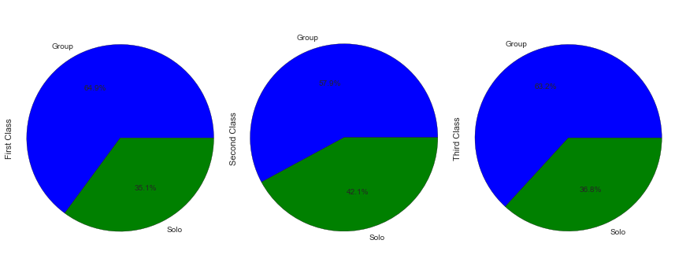

```python
fig = plt.figure(figsize=(12,5))

fig.add_subplot(131)
get_count(first_class_female_passengers.groupby('isSolo')).plot.pie(labels=['Group', 'Solo'],\
                                                                            label = 'First Class', \
                                                                            autopct='%1.1f%%')
plt.axis('equal')

fig.add_subplot(132)
get_count(second_class_female_passengers.groupby('isSolo')).plot.pie(labels=['Group', 'Solo'],\
                                                                             label = 'Second Class', \
                                                                             autopct='%1.1f%%')
plt.axis('equal')

fig.add_subplot(133)
get_count(third_class_female_passengers.groupby('isSolo')).plot.pie(labels=['Group', 'Solo'],\
                                                                            label = 'Third Class', \
                                                                            autopct='%1.1f%%')
plt.axis('equal')

plt.tight_layout()
```

#### Solo Women Traveling, by Class

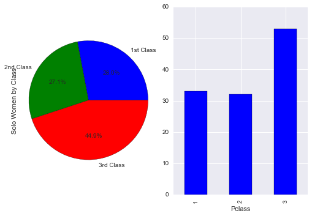

```python
first_class_solo_women_passengers =  solo_female_passengers[ solo_female_passengers['Pclass'] == 1 ]
second_class_solo_women_passengers =  solo_female_passengers[ solo_female_passengers['Pclass'] == 2 ]
third_class_solo_women_passengers =  solo_female_passengers[ solo_female_passengers['Pclass'] == 3 ]

fig = plt.figure(figsize=(7,5))
fig.add_subplot(121)
get_count(solo_female_passengers.groupby('Pclass')).plot.pie(label = 'Solo Women by Class',\
                                                                         labels = ['1st Class', '2nd Class', '3rd Class'],\
                                                                                autopct='%1.1f%%')
plt.axis('equal')

fig.add_subplot(122)
get_count(solo_female_passengers.groupby('Pclass')).plot.bar()

plt.tight_layout()
```

The class, visually, does not look to like it has an effect over the women's traveling companionship pattern.

### Men Traveling Companionship Pattern

Now, let us have a closer look at the male's traveling companionship; just to make the picture complete:

```
Men traveling alone:      403  Percentage: 69.84%
Men traveling in a group: 174  Percentage: 30.16%
```

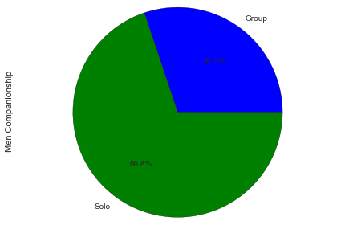

```python
get_count(passengers_by_gender.get_group('male').groupby('isSolo')).plot.pie(labels=['Group', 'Solo'], \
                                                                                         label = " Men Companionship", \
                                                                                         autopct='%1.1f%%')
plt.axis('equal')

plt.tight_layout()

group_men_count = get_count(passengers_by_gender.get_group('male').groupby('isSolo'))[0]
solo_men_count = get_count(passengers_by_gender.get_group('male').groupby('isSolo'))[1]

print "Men traveling alone:      " + str(solo_men_count) + "  Percentage: " + str ( format((float(solo_men_count) / male_count )*100.0, '.2f')) + "%"
print "Men traveling in a group: "+ str(group_men_count) + "  Percentage: " + str( format((float(group_men_count) / male_count )*100.0, '.2f')) + "%"
```

#### Men Traveling Companionship, by Class

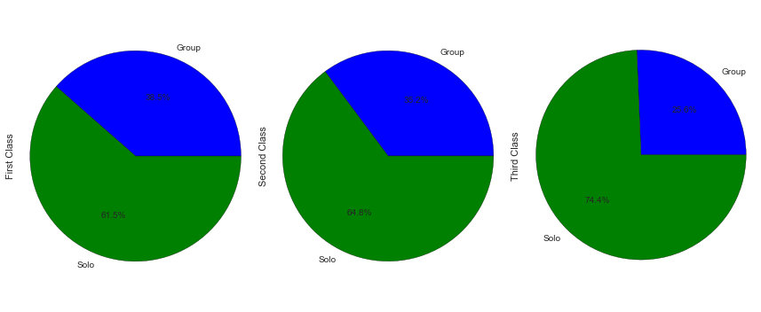

```python
fig = plt.figure(figsize=(12,5))

fig.add_subplot(131)
get_count(first_class_male_passengers.groupby('isSolo')).plot.pie(labels=['Group', 'Solo'],\
                                                                              label = 'First Class', \
                                                                              autopct='%1.1f%%')
plt.axis('equal')

fig.add_subplot(132)
get_count(second_class_male_passengers.groupby('isSolo')).plot.pie(labels=['Group', 'Solo'],\
                                                                               label = 'Second Class', \
                                                                               autopct='%1.1f%%')
plt.axis('equal')

fig.add_subplot(133)
get_count(third_class_male_passengers.groupby('isSolo')).plot.pie(labels=['Group', 'Solo'],\
                                                                              label = 'Third Class', \
                                                                              autopct='%1.1f%%')
plt.axis('equal')

plt.tight_layout()
```

#### Solo Men Traveling, by Class

[figure not shown]

```python
first_class_solo_men_passengers =  solo_male_passengers[ solo_male_passengers['Pclass'] == 1 ]
second_class_solo_men_passengers =  solo_male_passengers[ solo_male_passengers['Pclass'] == 2 ]
third_class_solo_men_passengers =  solo_male_passengers[ solo_male_passengers['Pclass'] == 3 ]

fig = plt.figure()
fig.add_subplot(121)
get_count(solo_male_passengers.groupby('Pclass')).plot.pie(label = 'Solo Women by Class', \
                                                                       autopct='%1.1f%%')
plt.axis('equal')

fig.add_subplot(122)
get_count(solo_male_passengers.groupby('Pclass')).plot.bar()

plt.tight_layout()
```

### Survival By Companionship

Now, down to the visualization of our first question: how does survival chance look like when seen through the lense of companionship?

[figure not shown]

```python
fig = plt.figure(figsize=(9,6))

draw_pie_subplot( surviving_passengers.groupby(surviving_passengers['isSolo']) , 121, 'Solo Survival', 'SURVIVAL_GRAPH')

draw_pie_subplot( victim_passengers.groupby(victim_passengers['isSolo']) , 122, 'Group Survival', 'SURVIVAL_GRAPH')

plt.tight_layout()
```

# Analysis

## Q1: What is the effect of Traveling Companionship Over the Survival of a Grown Up Passengers ?

### Descriptive Statistics

#### Total Companions, For All Passengers

```python
titanic_all_data['TotalCompanions'].describe()
```

```
count    891.000000
mean       0.904602
std        1.613459
min        0.000000
25%        0.000000
50%        0.000000
75%        1.000000
max       10.000000
Name: TotalCompanions, dtype: float64
```

#### Total Companions, For Group Travelers

```python
group_passengers = passengers_by_companionship.get_group(False);
solo_passengers = passengers_by_companionship.get_group(True)

group_passengers['TotalCompanions'].describe()
```

```
count    370.000000
mean       2.178378
std        1.869906
min        0.000000
25%        1.000000
50%        2.000000
75%        2.000000
max       10.000000
Name: TotalCompanions, dtype: float64
```

I think it is noteworthy to remind here that, the data has 0 as its minimum for the total number of companions (although we are examining the group passengers) is due to the choice of including children with the group travelers.

**The statistics for solo travelers will not be performed, since all the data (Except to the count) is equal to zero**

```python
group_passengers['Survived'].describe()
```

```
count    370.000000
mean       0.505405
std        0.500648
min        0.000000
25%        0.000000
50%        1.000000
75%        1.000000
max        1.000000
Name: Survived, dtype: float64
```

```python
solo_passengers['Survived'].describe()
```

```
count    521.000000
mean       0.297505
std        0.457600
min        0.000000
25%        0.000000
50%        0.000000
75%        1.000000
max        1.000000
Name: Survived, dtype: float64
```

### Hypothesis Testing:

The contingency table will be built so we can examine the relationship and perform the hypothesis testing

```python
#Expected frequency: Total survival, total drowning
#Solo
group_passengers_survived_count = get_count(group_passengers.groupby('Survived').get_group(1))
group_passengers_victims_count = get_count(group_passengers.groupby('Survived').get_group(0))

#Group
solo_passengers_survived_count = get_count(solo_passengers.groupby('Survived').get_group(1))
solo_passengers_victims_count = get_count(solo_passengers.groupby('Survived').get_group(0))

# passengers_by_survival
survivors_count_list = [group_passengers_survived_count, solo_passengers_survived_count,  total_survivors_count]
victims_count_list = [group_passengers_victims_count, solo_passengers_victims_count, total_victims_count]
total_count_list = [get_count(group_passengers), get_count(solo_passengers), sample_size]

#Had to pass the - redundunt - column argument to skip Pandas default ordering
contingency_table = pd.DataFrame({'Survived': survivors_count_list , \
                                  'Victims': victims_count_list , \
                                  'Total, Group': total_count_list},\
                                   index = ['Group', 'Solo', 'Total, State'], columns = [ 'Survived', 'Victims', 'Total, Group'])

display_html(contingency_table)
```

|  | Survived | Victims | Total, Group |
| --- | --- | --- | --- |
| Group | 187 | 183 | 370 |
| Solo | 155 | 366 | 521 |
| Total, State | 342 | 549 | 891 |

Now, all is set to calculate the Χ<sup>2</sup>

```python
chi_squared, p, degrees_of_freedom, expected_frequency = scipy.stats.chi2_contingency( contingency_table )

print "Chi Squared: ", chi_squared
print "p value: ", p
print "Degrees of Freedom", degrees_of_freedom
print "Expected Frequency for The Group Passengers:", expected_frequency[0]
print "Expected Frequency for The Solo Passengers:", expected_frequency[1]
```

```
Chi Squared:  39.539412799
p value:  5.38959286299e-08
Degrees of Freedom 4
Expected Frequency for The Group Passengers: [ 142.02020202  227.97979798  370.        ]
Expected Frequency for The Solo Passengers: [ 199.97979798  321.02020202  521.        ]
```

The statistical significance here is very high, but I this can be affected by children: Probably there are a good portion of children traveling with their families, and that can lead to a higher than usual women and children presence in the group passengers, and lower than usual presence of women in the solo group (By our definition of a solo group, a child cannot be solo even if Parch and SibSp are equal to zero). Let us examine how much women and children are present in the groups.

```python
women_and_children_group_passengers = titanic_all_data[ (titanic_all_data['Sex'] == 'female') | \
                                                       (titanic_all_data['Generation'] == 'Child')]
women_and_children_group_passengers_count = get_count(women_and_children_group_passengers)

print "Number of women and children in the group travelers: ", women_and_children_group_passengers_count
print "Percentage of women and children in the group traveler: ",\
(float(women_and_children_group_passengers_count)/ get_count(group_passengers))*100.0 , "%"
```

[output not shown]

**There could be other instances, of course, than a family made of both parents and children that can bring more grown up men to the count, like adult male brothers traveling together or a grown up son traveling with his elderly father**

I will try to refine the hypothesis, by excluding children from the group data, and just compare grown up passengers (adults and elderly) from both groups.

**Note: The two grownup variables do not have the members whose age is unknown, they contain only members that we know for sure that they are adults**

```python
passengers_by_generation = titanic_all_data.groupby('Generation')

#The output will be a dictionary, with keys Adult and Elderly
passengers_by_grown_up = {key: value for key, value in passengers_by_generation if key in ['Adult', 'Elderly']}

#Now, expand the values of the dictionary into a dataframe
grown_up_passengers = pd.concat([grown_up_passengers_values for keys, grown_up_passengers_values in passengers_by_grown_up.items()])

#Get the count of survival. This will be used as our expected count for the Chi square computation
grown_up_survival_count = get_count(grown_up_passengers.groupby('Survived'))

#The append function did not behave as I expected, ie it did not perform its action in place nor did it have an inplace parameter.
#I had to take the whole thing and make it equal to the Series in question
#Also, the index = [2] is done to prevent index duplicates, otherwise the total will be added with index 0. It would not really
#affect the calculation, but it affected when I wanted to rename the indices for readability
grown_up_survival_count = grown_up_survival_count.append( pd.Series(len(grown_up_passengers), index = [2] ))

#Separate passengers by companionship
group_grown_up_passengers = grown_up_passengers.groupby('isSolo').get_group(0)
solo_grown_up_passengers = grown_up_passengers.groupby('isSolo').get_group(1)

#Get the survival for each group and solo grown up passengers
group_grown_up_passengers_survival_count = get_count(group_grown_up_passengers.groupby('Survived'))
solo_grown_up_passengers_survival_count = get_count(solo_grown_up_passengers.groupby('Survived'))

#Append the total to each series
group_grown_up_passengers_survival_count = group_grown_up_passengers_survival_count.append( pd.Series(len(group_grown_up_passengers), index = [2] ))
solo_grown_up_passengers_survival_count = solo_grown_up_passengers_survival_count.append( pd.Series(len(solo_grown_up_passengers), index = [2] ))


#Build the contingency table
contingency_table = pd.concat([ group_grown_up_passengers_survival_count, solo_grown_up_passengers_survival_count, grown_up_survival_count],\
                              axis=1, \
                              keys ={'Group','Solo','Total'})

contingency_table.rename(index= { 0 : 'Victims', 1 : 'Survivors', 2 : 'Total'},\
                         inplace = True)

contingency_table
```

[output not shown]

Next, it is the Chi square for the adult passengers, by companionship:

```python
chi_squared, p, degrees_of_freedom, expected_frequency = scipy.stats.chi2_contingency( contingency_table )

print "Chi Squared: ", chi_squared
print "p value: ", p
print "Degrees of Freedom", degrees_of_freedom
print "Expected Frequency for The Group Passengers:", expected_frequency[0]
print "Expected Frequency for The Solo Passengers:", expected_frequency[1]
```

```
Chi Squared:  20.8162744573
p value:  0.000344364339067
Degrees of Freedom 4
Expected Frequency for The Group Passengers: [ 139.50162866  239.49837134  379.        ]
Expected Frequency for The Solo Passengers: [  86.49837134  148.50162866  235.        ]
```

**Well, the results were shifted towards the mean by orders of magnitude after removing the children, but still they are very statistically significant even under the most conservative standards. The chances to get such a sample is about 1 in 3000, very low indeed.**

#### Calculate The Effect Size (Cohen d)

```python
avergae_std = (group_passengers['Survived'].std() + solo_passengers['Survived'].std()) / 2
cohens_d = abs(solo_passengers['Survived'].mean() - group_passengers['Survived'].mean() )/avergae_std
print "Cohen d: ", cohens_d
```

```
Cohen d:  0.43391833554
```

### Conclusion For Q1:

**p < α**

Χ<sup>2</sup> = 20.82, p < 0.001, two tailed

**Effect Size Measures:**

- d = 0.43

NB: I have based this way of writing up the conclusion from the book "Statistics in plain english"

**A chi-square analysis was performed to determine whether traveling companionship affected the chances of survival for a passenger.The analysis produced a significant χ2 value (39.54, df = 4, p < .001), indicating that traveling with first degree family affected the chances of survival. The question was then refined, by removing the children passengers since they had the best survival chances, and were absent from the Solo passengers group because of how we defined who is a solo traveler. The new χ2 value remained significant (20.82, df = 4, p < .001) although less than the original question by orders of magnitude. Therefore, we must reject the null hypothesis.**

The limitation I have found is that, since the question under investigation involved categorizing passengers based over their age, missing ages meant that the test was not done all over the sample, but only a fraction of it. I have opted to omit passengers with missing ages rather than making any other assumptions (Like assuming their age is mean\median, or even assume that their age distribution is the same as the that of the bigger sample) since I had a good amount of data already to run the test; so there was no need to take any risks by making extra assumptions.

The data field that I wanted to have, although it can be hard to get - especially for adult passengers -, is who are they traveling with other than the immediate family. Cousins, friends..etc could have proved useful for such a question. The reason I have picked this question from the first place is that, I imagined what might have been the situation on deck during such a hard time, and I though that a group of people who care for each other can be useful in such an extreme situation: they can push, fight, beg or even something illegal like bribe to save all the rest of the group, a priviliged support that a solo traveler would not have. Of course the immediate family might be the most aggressive\protective, but still cousins and close friends can provide a comparable support.

## Q2: Is It Possible From The Provided Data To Identify Family Members?

The problem with this question is that this is only a partial data, so numbers will not add up: there could be other family members in the other set. But I will proceed anyway. So here are my assumptions:

- Same family travels within the same class
- Same family bears the same last name
- Same family share the same number of TotalCompanions
- Children with TotalCompanions == 0 will be excluded. Of course common sense tells that they are not traveling alone, but the thing is that, according to the provided data, they are not traveling with their immediate family.

```python
group_family = group_passengers[ group_passengers['TotalCompanions'] > 0 ]
group_by_family_size = group_family.groupby(['TotalCompanions','Pclass', 'LastName'])#, sort=False)



#We are going to create three lists, one for all the families whose members have NOT survived
#Another for the families which had some members who survived but not all
#The third is for the families whose all members were able to make it
families_totally_perished = []
families_partially_saved = []
families_totally_saved = []

#Now, let's loop over the groupby of family by size created above, and check which family belongs
#to which of the three lists created above

#Loop over the group
#tc = TotalCompanions, pcls = pclass, lname = LastName. There was no need to unpack the keys, but I am going to leave it
#that way.
for (tc, pcls, lname), data in group_by_family_size:
    n = 0

    #A variable to count how many members survived within the same family
    saved_count = 0

    #Loop over each member within the same family
    for current_family_member in range(len(data)):
        #If the current member in the loop has survived, increment the saved count
        if data.iloc[current_family_member]['Survived'] == 1:
            saved_count += 1
    #After looping over all family members, now let us check the count to decide in which of the 3 lists
    #are we going to add the family to
    if saved_count == 0:
        families_totally_perished.append(data)
    #If the total count is not equal to the total companions + 1. We add one here because the family size
    # is always greater than the total companions by one. This is because the count always tells the number
    #of other family members within the family of the passenger, but does not count the passenger himself\herself
    elif (saved_count != (data.iloc[current_family_member]['TotalCompanions'] + 1) ):
        families_partially_saved.append(data)
    else:
        families_totally_saved.append(data)


#A function that will display each list as a table. The three lists to display are:
#families_totally_perished
#families_partially_saved
#families_totally_saved
def display_family_list(family_list):
    #Loop over each family within the passed list
    for family in family_list:
        #Create the container dataframe. THis data frame will hold temporarily all members that belong to the same family
        #Later on, this dataframe will be used to display the family in a table
        df = pd.DataFrame( columns=("Generation", 'Sex', 'Age', 'Name', 'Class','PassengerId'))

        #Print the name of the family, and then print on a new line how many members the family has
        print "The " + str(family.iloc[0]['LastName']) + " Family: "
        print "The Family had " + str(family.iloc[0]['TotalCompanions'] + 1) + " members on board"


        #Write how many family members from the current family were present in the data set
        #If the number of family members within the set is equal to the total family size (Companions + 1),
        #the print that all family members were present in the data set
        if( (len(family)) == (family.iloc[0]['TotalCompanions'] + 1) ):
            print "All of the family members were available in the dataset"
        #Else, write how many family members were present in the data set
        else:
            #Just some nice formatting, divide the singular and plural
            if(len(family) == 1):
                print ' --> Only one member was available in the dataset'
            else:
                print " --> Only "+ str(len(family)) + " members were available in the dataset"

        #Loop over each family member within the current family
        for i in range(len(family)):
            #Append the current family member to the dataframe, so that member would be displayed inside the same table.
            df = df.append( {"Generation":family.iloc[i]['Generation'],\
                             'Sex':family.iloc[i]['Sex'], \
                             'Age':family.iloc[i]['Age'], \
                             'Name': family.iloc[i]['Name'],\
                             'Class': family.iloc[i]['Pclass'],\
                             'PassengerId': family.iloc[i]['PassengerId'] } , ignore_index=True )
            #df = df.append([1,2,3,4],ignore_index=True)
        display_html(df)
        print '_________________________________________________________________'
```

### Families Whose Members Within The Dataset That Never Made It

```python
display_family_list(families_totally_perished)
```

```
The Cavendish Family:
The Family had 2 members on board
 --> Only one member was available in the dataset
```

|  | Generation | Sex | Age | Name | Class | PassengerId |
| --- | --- | --- | --- | --- | --- | --- |
| 0 | Adult | male | 36 | Cavendish, Mr. Tyrell William | 1 | 742 |

```
_________________________________________________________________
The Chaffee Family:
The Family had 2 members on board
 --> Only one member was available in the dataset
```

|  | Generation | Sex | Age | Name | Class | PassengerId |
| --- | --- | --- | --- | --- | --- | --- |
| 0 | Adult | male | 46 | Chaffee, Mr. Herbert Fuller | 1 | 93 |

```
_________________________________________________________________
The Davidson Family:
The Family had 2 members on board
 --> Only one member was available in the dataset
```

|  | Generation | Sex | Age | Name | Class | PassengerId |
| --- | --- | --- | --- | --- | --- | --- |
| 0 | Adult | male | 31 | Davidson, Mr. Thornton | 1 | 672 |

```
_________________________________________________________________
The Douglas Family:
The Family had 2 members on board
 --> Only one member was available in the dataset
```

|  | Generation | Sex | Age | Name | Class | PassengerId |
| --- | --- | --- | --- | --- | --- | --- |
| 0 | Elderly | male | 50 | Douglas, Mr. Walter Donald | 1 | 545 |

```
_________________________________________________________________
The Marvin Family:
The Family had 2 members on board
 --> Only one member was available in the dataset
```

|  | Generation | Sex | Age | Name | Class | PassengerId |
| --- | --- | --- | --- | --- | --- | --- |
| 0 | Adult | male | 19 | Marvin, Mr. Daniel Warner | 1 | 749 |

```
_________________________________________________________________
The Natsch Family:
The Family had 2 members on board
 --> Only one member was available in the dataset
```

|  | Generation | Sex | Age | Name | Class | PassengerId |
| --- | --- | --- | --- | --- | --- | --- |
| 0 | Adult | male | 37 | Natsch, Mr. Charles H | 1 | 274 |

```
_________________________________________________________________
The Ostby Family:
The Family had 2 members on board
 --> Only one member was available in the dataset
```

|  | Generation | Sex | Age | Name | Class | PassengerId |
| --- | --- | --- | --- | --- | --- | --- |
| 0 | Elderly | male | 65 | Ostby, Mr. Engelhart Cornelius | 1 | 55 |

```
_________________________________________________________________
The White Family:
The Family had 2 members on board
All of the family members were available in the dataset
```

|  | Generation | Sex | Age | Name | Class | PassengerId |
| --- | --- | --- | --- | --- | --- | --- |
| 0 | Adult | male | 21 | White, Mr. Richard Frasar | 1 | 103 |
| 1 | Elderly | male | 54 | White, Mr. Percival Wayland | 1 | 125 |

```
_________________________________________________________________
The Williams Family:
The Family had 2 members on board
 --> Only one member was available in the dataset
```

|  | Generation | Sex | Age | Name | Class | PassengerId |
| --- | --- | --- | --- | --- | --- | --- |
| 0 | Elderly | male | 51 | Williams, Mr. Charles Duane | 1 | 156 |

```
_________________________________________________________________
The Bryhl Family:
The Family had 2 members on board
 --> Only one member was available in the dataset
```

|  | Generation | Sex | Age | Name | Class | PassengerId |
| --- | --- | --- | --- | --- | --- | --- |
| 0 | Adult | male | 25 | Bryhl, Mr. Kurt Arnold Gottfrid | 2 | 729 |

```
_________________________________________________________________
The Carter Family:
The Family had 2 members on board
All of the family members were available in the dataset
```

|  | Generation | Sex | Age | Name | Class | PassengerId |
| --- | --- | --- | --- | --- | --- | --- |
| 0 | Elderly | male | 54 | Carter, Rev. Ernest Courtenay | 2 | 250 |
| 1 | Adult | female | 44 | Carter, Mrs. Ernest Courtenay (Lilian Hughes) | 2 | 855 |

```
_________________________________________________________________
The Chapman Family:
The Family had 2 members on board
 --> Only one member was available in the dataset
```

|  | Generation | Sex | Age | Name | Class | PassengerId |
| --- | --- | --- | --- | --- | --- | --- |
| 0 | Adult | male | 37 | Chapman, Mr. John Henry | 2 | 595 |

```
_________________________________________________________________
The Gale Family:
The Family had 2 members on board
 --> Only one member was available in the dataset
```

|  | Generation | Sex | Age | Name | Class | PassengerId |
| --- | --- | --- | --- | --- | --- | --- |
| 0 | Adult | male | 34 | Gale, Mr. Shadrach | 2 | 406 |

```
_________________________________________________________________
The Giles Family:
The Family had 2 members on board
 --> Only one member was available in the dataset
```

|  | Generation | Sex | Age | Name | Class | PassengerId |
| --- | --- | --- | --- | --- | --- | --- |
| 0 | Adult | male | 21 | Giles, Mr. Frederick Edward | 2 | 862 |

```
_________________________________________________________________
The Hold Family:
The Family had 2 members on board
 --> Only one member was available in the dataset
```

|  | Generation | Sex | Age | Name | Class | PassengerId |
| --- | --- | --- | --- | --- | --- | --- |
| 0 | Adult | male | 44 | Hold, Mr. Stephen | 2 | 237 |

```
_________________________________________________________________
The Jacobsohn Family:
The Family had 2 members on board
 --> Only one member was available in the dataset
```

|  | Generation | Sex | Age | Name | Class | PassengerId |
| --- | --- | --- | --- | --- | --- | --- |
| 0 | Adult | male | 42 | Jacobsohn, Mr. Sidney Samuel | 2 | 218 |

```
_________________________________________________________________
The Renouf Family:
The Family had 2 members on board
 --> Only one member was available in the dataset
```

|  | Generation | Sex | Age | Name | Class | PassengerId |
| --- | --- | --- | --- | --- | --- | --- |
| 0 | Adult | male | 34 | Renouf, Mr. Peter Henry | 2 | 477 |

```
_________________________________________________________________
The Turpin Family:
The Family had 2 members on board
All of the family members were available in the dataset
```

|  | Generation | Sex | Age | Name | Class | PassengerId |
| --- | --- | --- | --- | --- | --- | --- |
| 0 | Adult | female | 27 | Turpin, Mrs. William John Robert (Dorothy Ann ... | 2 | 42 |
| 1 | Adult | male | 29 | Turpin, Mr. William John Robert | 2 | 118 |

```
_________________________________________________________________
The del Carlo Family:
The Family had 2 members on board
 --> Only one member was available in the dataset
```

|  | Generation | Sex | Age | Name | Class | PassengerId |
| --- | --- | --- | --- | --- | --- | --- |
| 0 | Adult | male | 29 | del Carlo, Mr. Sebastiano | 2 | 362 |

```
_________________________________________________________________
The Ahlin Family:
The Family had 2 members on board
 --> Only one member was available in the dataset
```

|  | Generation | Sex | Age | Name | Class | PassengerId |
| --- | --- | --- | --- | --- | --- | --- |
| 0 | Adult | female | 40 | Ahlin, Mrs. Johan (Johanna Persdotter Larsson) | 3 | 41 |

```
_________________________________________________________________
The Arnold-Franchi Family:
The Family had 2 members on board
All of the family members were available in the dataset
```

|  | Generation | Sex | Age | Name | Class | PassengerId |
| --- | --- | --- | --- | --- | --- | --- |
| 0 | Adult | female | 18 | Arnold-Franchi, Mrs. Josef (Josefine Franchi) | 3 | 50 |
| 1 | Adult | male | 25 | Arnold-Franchi, Mr. Josef | 3 | 354 |

```
_________________________________________________________________
The Backstrom Family:
The Family had 2 members on board
 --> Only one member was available in the dataset
```

|  | Generation | Sex | Age | Name | Class | PassengerId |
| --- | --- | --- | --- | --- | --- | --- |
| 0 | Adult | male | 32 | Backstrom, Mr. Karl Alfred | 3 | 207 |

```
_________________________________________________________________
The Barbara Family:
The Family had 2 members on board
All of the family members were available in the dataset
```

|  | Generation | Sex | Age | Name | Class | PassengerId |
| --- | --- | --- | --- | --- | --- | --- |
| 0 | Adult | female | 45 | Barbara, Mrs. (Catherine David) | 3 | 363 |
| 1 | Adult | female | 18 | Barbara, Miss. Saiide | 3 | 703 |

```
_________________________________________________________________
The Braund Family:
The Family had 2 members on board
All of the family members were available in the dataset
```

|  | Generation | Sex | Age | Name | Class | PassengerId |
| --- | --- | --- | --- | --- | --- | --- |
| 0 | Adult | male | 22 | Braund, Mr. Owen Harris | 3 | 1 |
| 1 | Adult | male | 29 | Braund, Mr. Lewis Richard | 3 | 478 |

```
_________________________________________________________________
The Caram Family:
The Family had 2 members on board
 --> Only one member was available in the dataset
```

|  | Generation | Sex | Age | Name | Class | PassengerId |
| --- | --- | --- | --- | --- | --- | --- |
| 0 | Unspecified age | female | NaN | Caram, Mrs. Joseph (Maria Elias) | 3 | 579 |

```
_________________________________________________________________
The Chronopoulos Family:
The Family had 2 members on board
 --> Only one member was available in the dataset
```

|  | Generation | Sex | Age | Name | Class | PassengerId |
| --- | --- | --- | --- | --- | --- | --- |
| 0 | Adult | male | 26 | Chronopoulos, Mr. Apostolos | 3 | 74 |

```
_________________________________________________________________
The Cribb Family:
The Family had 2 members on board
 --> Only one member was available in the dataset
```

|  | Generation | Sex | Age | Name | Class | PassengerId |
| --- | --- | --- | --- | --- | --- | --- |
| 0 | Adult | male | 44 | Cribb, Mr. John Hatfield | 3 | 161 |

```
_________________________________________________________________
The Hagland Family:
The Family had 2 members on board
All of the family members were available in the dataset
```

|  | Generation | Sex | Age | Name | Class | PassengerId |
| --- | --- | --- | --- | --- | --- | --- |
| 0 | Unspecified age | male | NaN | Hagland, Mr. Ingvald Olai Olsen | 3 | 452 |
| 1 | Unspecified age | male | NaN | Hagland, Mr. Konrad Mathias Reiersen | 3 | 491 |

```
_________________________________________________________________
The Hansen Family:
The Family had 2 members on board
 --> Only one member was available in the dataset
```

|  | Generation | Sex | Age | Name | Class | PassengerId |
| --- | --- | --- | --- | --- | --- | --- |
| 0 | Adult | male | 26 | Hansen, Mr. Henrik Juul | 3 | 705 |

```
_________________________________________________________________
The Ilmakangas Family:
The Family had 2 members on board
 --> Only one member was available in the dataset
```

|  | Generation | Sex | Age | Name | Class | PassengerId |
| --- | --- | --- | --- | --- | --- | --- |
| 0 | Adult | female | 25 | Ilmakangas, Miss. Pieta Sofia | 3 | 730 |

```
_________________________________________________________________
The Jensen Family:
The Family had 2 members on board
 --> Only one member was available in the dataset
```

|  | Generation | Sex | Age | Name | Class | PassengerId |
| --- | --- | --- | --- | --- | --- | --- |
| 0 | Adult | male | 17 | Jensen, Mr. Svend Lauritz | 3 | 722 |

```
_________________________________________________________________
The Jussila Family:
The Family had 2 members on board
All of the family members were available in the dataset
```

|  | Generation | Sex | Age | Name | Class | PassengerId |
| --- | --- | --- | --- | --- | --- | --- |
| 0 | Adult | female | 20 | Jussila, Miss. Katriina | 3 | 114 |
| 1 | Adult | female | 21 | Jussila, Miss. Mari Aina | 3 | 403 |

```
_________________________________________________________________
The Kiernan Family:
The Family had 2 members on board
 --> Only one member was available in the dataset
```

|  | Generation | Sex | Age | Name | Class | PassengerId |
| --- | --- | --- | --- | --- | --- | --- |
| 0 | Unspecified age | male | NaN | Kiernan, Mr. Philip | 3 | 215 |

```
_________________________________________________________________
The Lennon Family:
The Family had 2 members on board
 --> Only one member was available in the dataset
```

|  | Generation | Sex | Age | Name | Class | PassengerId |
| --- | --- | --- | --- | --- | --- | --- |
| 0 | Unspecified age | male | NaN | Lennon, Mr. Denis | 3 | 47 |

```
_________________________________________________________________
The Lindell Family:
The Family had 2 members on board
 --> Only one member was available in the dataset
```

|  | Generation | Sex | Age | Name | Class | PassengerId |
| --- | --- | --- | --- | --- | --- | --- |
| 0 | Adult | male | 36 | Lindell, Mr. Edvard Bengtsson | 3 | 606 |

```
_________________________________________________________________
The Lobb Family:
The Family had 2 members on board
All of the family members were available in the dataset
```

|  | Generation | Sex | Age | Name | Class | PassengerId |
| --- | --- | --- | --- | --- | --- | --- |
| 0 | Adult | male | 30 | Lobb, Mr. William Arthur | 3 | 254 |
| 1 | Adult | female | 26 | Lobb, Mrs. William Arthur (Cordelia K Stanlick) | 3 | 618 |

```
_________________________________________________________________
The McNamee Family:
The Family had 2 members on board
 --> Only one member was available in the dataset
```

|  | Generation | Sex | Age | Name | Class | PassengerId |
| --- | --- | --- | --- | --- | --- | --- |
| 0 | Adult | male | 24 | McNamee, Mr. Neal | 3 | 744 |

```
_________________________________________________________________
The Olsen Family:
The Family had 2 members on board
 --> Only one member was available in the dataset
```

|  | Generation | Sex | Age | Name | Class | PassengerId |
| --- | --- | --- | --- | --- | --- | --- |
| 0 | Adult | male | 42 | Olsen, Mr. Karl Siegwart Andreas | 3 | 198 |

```
_________________________________________________________________
The Petterson Family:
The Family had 2 members on board
 --> Only one member was available in the dataset
```

|  | Generation | Sex | Age | Name | Class | PassengerId |
| --- | --- | --- | --- | --- | --- | --- |
| 0 | Adult | male | 25 | Petterson, Mr. Johan Emil | 3 | 443 |

```
_________________________________________________________________
The Robins Family:
The Family had 2 members on board
 --> Only one member was available in the dataset
```

|  | Generation | Sex | Age | Name | Class | PassengerId |
| --- | --- | --- | --- | --- | --- | --- |
| 0 | Adult | female | 47 | Robins, Mrs. Alexander A (Grace Charity Laury) | 3 | 133 |

```
_________________________________________________________________
The Strom Family:
The Family had 2 members on board
 --> Only one member was available in the dataset
```

|  | Generation | Sex | Age | Name | Class | PassengerId |
| --- | --- | --- | --- | --- | --- | --- |
| 0 | Child | female | 2 | Strom, Miss. Telma Matilda | 3 | 206 |

```
_________________________________________________________________
The Vander Planke Family:
The Family had 2 members on board
 --> Only one member was available in the dataset
```

|  | Generation | Sex | Age | Name | Class | PassengerId |
| --- | --- | --- | --- | --- | --- | --- |
| 0 | Adult | female | 31 | Vander Planke, Mrs. Julius (Emelia Maria Vande... | 3 | 19 |

```
_________________________________________________________________
The Wiklund Family:
The Family had 2 members on board
 --> Only one member was available in the dataset
```

|  | Generation | Sex | Age | Name | Class | PassengerId |
| --- | --- | --- | --- | --- | --- | --- |
| 0 | Adult | male | 18 | Wiklund, Mr. Jakob Alfred | 3 | 372 |

```
_________________________________________________________________
The Zabour Family:
The Family had 2 members on board
All of the family members were available in the dataset
```

|  | Generation | Sex | Age | Name | Class | PassengerId |
| --- | --- | --- | --- | --- | --- | --- |
| 0 | Child | female | 14.5 | Zabour, Miss. Hileni | 3 | 112 |
| 1 | Unspecified age | female | NaN | Zabour, Miss. Thamine | 3 | 241 |

```
_________________________________________________________________
The Minahan Family:
The Family had 3 members on board
 --> Only one member was available in the dataset
```

|  | Generation | Sex | Age | Name | Class | PassengerId |
| --- | --- | --- | --- | --- | --- | --- |
| 0 | Adult | male | 44 | Minahan, Dr. William Edward | 1 | 246 |

```
_________________________________________________________________
The Newell Family:
The Family had 3 members on board
 --> Only one member was available in the dataset
```

|  | Generation | Sex | Age | Name | Class | PassengerId |
| --- | --- | --- | --- | --- | --- | --- |
| 0 | Elderly | male | 58 | Newell, Mr. Arthur Webster | 1 | 660 |

```
_________________________________________________________________
The Widener Family:
The Family had 3 members on board
 --> Only one member was available in the dataset
```

|  | Generation | Sex | Age | Name | Class | PassengerId |
| --- | --- | --- | --- | --- | --- | --- |
| 0 | Adult | male | 27 | Widener, Mr. Harry Elkins | 1 | 378 |

```
_________________________________________________________________
The Hickman Family:
The Family had 3 members on board
All of the family members were available in the dataset
```

|  | Generation | Sex | Age | Name | Class | PassengerId |
| --- | --- | --- | --- | --- | --- | --- |
| 0 | Adult | male | 21 | Hickman, Mr. Stanley George | 2 | 121 |
| 1 | Adult | male | 24 | Hickman, Mr. Leonard Mark | 2 | 656 |
| 2 | Adult | male | 32 | Hickman, Mr. Lewis | 2 | 666 |

```
_________________________________________________________________
The Lahtinen Family:
The Family had 3 members on board
 --> Only one member was available in the dataset
```

|  | Generation | Sex | Age | Name | Class | PassengerId |
| --- | --- | --- | --- | --- | --- | --- |
| 0 | Adult | female | 26 | Lahtinen, Mrs. William (Anna Sylfven) | 2 | 313 |

```
_________________________________________________________________
The Nicholls Family:
The Family had 3 members on board
 --> Only one member was available in the dataset
```

|  | Generation | Sex | Age | Name | Class | PassengerId |
| --- | --- | --- | --- | --- | --- | --- |
| 0 | Adult | male | 19 | Nicholls, Mr. Joseph Charles | 2 | 146 |

```
_________________________________________________________________
The Boulos Family:
The Family had 3 members on board
 --> Only 2 members were available in the dataset
```

|  | Generation | Sex | Age | Name | Class | PassengerId |
| --- | --- | --- | --- | --- | --- | --- |
| 0 | Unspecified age | female | NaN | Boulos, Mrs. Joseph (Sultana) | 3 | 141 |
| 1 | Child | female | 9 | Boulos, Miss. Nourelain | 3 | 853 |

```
_________________________________________________________________
The Bourke Family:
The Family had 3 members on board
All of the family members were available in the dataset
```

|  | Generation | Sex | Age | Name | Class | PassengerId |
| --- | --- | --- | --- | --- | --- | --- |
| 0 | Adult | male | 40 | Bourke, Mr. John | 3 | 189 |
| 1 | Unspecified age | female | NaN | Bourke, Miss. Mary | 3 | 594 |
| 2 | Adult | female | 32 | Bourke, Mrs. John (Catherine) | 3 | 658 |

```
_________________________________________________________________
The Danbom Family:
The Family had 3 members on board
 --> Only 2 members were available in the dataset
```

|  | Generation | Sex | Age | Name | Class | PassengerId |
| --- | --- | --- | --- | --- | --- | --- |
| 0 | Adult | female | 28 | Danbom, Mrs. Ernst Gilbert (Anna Sigrid Maria ... | 3 | 424 |
| 1 | Adult | male | 34 | Danbom, Mr. Ernst Gilbert | 3 | 617 |

```
_________________________________________________________________
The Davies Family:
The Family had 3 members on board
 --> Only one member was available in the dataset
```

|  | Generation | Sex | Age | Name | Class | PassengerId |
| --- | --- | --- | --- | --- | --- | --- |
| 0 | Adult | male | 24 | Davies, Mr. Alfred J | 3 | 566 |

```
_________________________________________________________________
The Elias Family:
The Family had 3 members on board
 --> Only 2 members were available in the dataset
```

|  | Generation | Sex | Age | Name | Class | PassengerId |
| --- | --- | --- | --- | --- | --- | --- |
| 0 | Child | male | 15 | Elias, Mr. Tannous | 3 | 353 |
| 1 | Adult | male | 17 | Elias, Mr. Joseph Jr | 3 | 533 |

```
_________________________________________________________________
The Gustafsson Family:
The Family had 3 members on board
 --> Only 2 members were available in the dataset
```

|  | Generation | Sex | Age | Name | Class | PassengerId |
| --- | --- | --- | --- | --- | --- | --- |
| 0 | Adult | male | 37 | Gustafsson, Mr. Anders Vilhelm | 3 | 105 |
| 1 | Adult | male | 28 | Gustafsson, Mr. Johan Birger | 3 | 393 |

```
_________________________________________________________________
The Hansen Family:
The Family had 3 members on board
 --> Only one member was available in the dataset
```

|  | Generation | Sex | Age | Name | Class | PassengerId |
| --- | --- | --- | --- | --- | --- | --- |
| 0 | Adult | male | 41 | Hansen, Mr. Claus Peter | 3 | 861 |

```
_________________________________________________________________
The Kink Family:
The Family had 3 members on board
 --> Only one member was available in the dataset
```

|  | Generation | Sex | Age | Name | Class | PassengerId |
| --- | --- | --- | --- | --- | --- | --- |
| 0 | Adult | male | 26 | Kink, Mr. Vincenz | 3 | 70 |

```
_________________________________________________________________
The Klasen Family:
The Family had 3 members on board
 --> Only one member was available in the dataset
```

|  | Generation | Sex | Age | Name | Class | PassengerId |
| --- | --- | --- | --- | --- | --- | --- |
| 0 | Adult | male | 18 | Klasen, Mr. Klas Albin | 3 | 176 |

```
_________________________________________________________________
The Rosblom Family:
The Family had 3 members on board
 --> Only 2 members were available in the dataset
```

|  | Generation | Sex | Age | Name | Class | PassengerId |
| --- | --- | --- | --- | --- | --- | --- |
| 0 | Adult | female | 41 | Rosblom, Mrs. Viktor (Helena Wilhelmina) | 3 | 255 |
| 1 | Adult | male | 18 | Rosblom, Mr. Viktor Richard | 3 | 425 |

```
_________________________________________________________________
The Samaan Family:
The Family had 3 members on board
 --> Only one member was available in the dataset
```

|  | Generation | Sex | Age | Name | Class | PassengerId |
| --- | --- | --- | --- | --- | --- | --- |
| 0 | Unspecified age | male | NaN | Samaan, Mr. Youssef | 3 | 49 |

```
_________________________________________________________________
The Strom Family:
The Family had 3 members on board
 --> Only one member was available in the dataset
```

|  | Generation | Sex | Age | Name | Class | PassengerId |
| --- | --- | --- | --- | --- | --- | --- |
| 0 | Adult | female | 29 | Strom, Mrs. Wilhelm (Elna Matilda Persson) | 3 | 252 |

```
_________________________________________________________________
The Van Impe Family:
The Family had 3 members on board
All of the family members were available in the dataset
```

|  | Generation | Sex | Age | Name | Class | PassengerId |
| --- | --- | --- | --- | --- | --- | --- |
| 0 | Child | female | 10 | Van Impe, Miss. Catharina | 3 | 420 |
| 1 | Adult | male | 36 | Van Impe, Mr. Jean Baptiste | 3 | 596 |
| 2 | Adult | female | 30 | Van Impe, Mrs. Jean Baptiste (Rosalie Paula Go... | 3 | 800 |

```
_________________________________________________________________
The Vander Planke Family:
The Family had 3 members on board
 --> Only 2 members were available in the dataset
```

|  | Generation | Sex | Age | Name | Class | PassengerId |
| --- | --- | --- | --- | --- | --- | --- |
| 0 | Adult | female | 18 | Vander Planke, Miss. Augusta Maria | 3 | 39 |
| 1 | Child | male | 16 | Vander Planke, Mr. Leo Edmondus | 3 | 334 |

```
_________________________________________________________________
The van Billiard Family:
The Family had 3 members on board
 --> Only one member was available in the dataset
```

|  | Generation | Sex | Age | Name | Class | PassengerId |
| --- | --- | --- | --- | --- | --- | --- |
| 0 | Adult | male | 40.5 | van Billiard, Mr. Austin Blyler | 3 | 154 |

```
_________________________________________________________________
The Hocking Family:
The Family had 4 members on board
 --> Only one member was available in the dataset
```

|  | Generation | Sex | Age | Name | Class | PassengerId |
| --- | --- | --- | --- | --- | --- | --- |
| 0 | Adult | male | 23 | Hocking, Mr. Richard George | 2 | 530 |

```
_________________________________________________________________
The Johnston Family:
The Family had 4 members on board
 --> Only 2 members were available in the dataset
```

|  | Generation | Sex | Age | Name | Class | PassengerId |
| --- | --- | --- | --- | --- | --- | --- |
| 0 | Unspecified age | male | NaN | Johnston, Mr. Andrew G | 3 | 784 |
| 1 | Unspecified age | female | NaN | Johnston, Miss. Catherine Helen "Carrie" | 3 | 889 |

```
_________________________________________________________________
The Ford Family:
The Family had 5 members on board
 --> Only 4 members were available in the dataset
```

|  | Generation | Sex | Age | Name | Class | PassengerId |
| --- | --- | --- | --- | --- | --- | --- |
| 0 | Child | male | 16 | Ford, Mr. William Neal | 3 | 87 |
| 1 | Child | female | 9 | Ford, Miss. Robina Maggie "Ruby" | 3 | 148 |
| 2 | Adult | female | 21 | Ford, Miss. Doolina Margaret "Daisy" | 3 | 437 |
| 3 | Adult | female | 48 | Ford, Mrs. Edward (Margaret Ann Watson) | 3 | 737 |

```
_________________________________________________________________
The Lefebre Family:
The Family had 5 members on board
 --> Only 4 members were available in the dataset
```

|  | Generation | Sex | Age | Name | Class | PassengerId |
| --- | --- | --- | --- | --- | --- | --- |
| 0 | Unspecified age | male | NaN | Lefebre, Master. Henry Forbes | 3 | 177 |
| 1 | Unspecified age | female | NaN | Lefebre, Miss. Mathilde | 3 | 230 |
| 2 | Unspecified age | female | NaN | Lefebre, Miss. Ida | 3 | 410 |
| 3 | Unspecified age | female | NaN | Lefebre, Miss. Jeannie | 3 | 486 |

```
_________________________________________________________________
The Palsson Family:
The Family had 5 members on board
 --> Only 4 members were available in the dataset
```

|  | Generation | Sex | Age | Name | Class | PassengerId |
| --- | --- | --- | --- | --- | --- | --- |
| 0 | Child | male | 2 | Palsson, Master. Gosta Leonard | 3 | 8 |
| 1 | Child | female | 8 | Palsson, Miss. Torborg Danira | 3 | 25 |
| 2 | Child | female | 3 | Palsson, Miss. Stina Viola | 3 | 375 |
| 3 | Adult | female | 29 | Palsson, Mrs. Nils (Alma Cornelia Berglund) | 3 | 568 |

```
_________________________________________________________________
The Panula Family:
The Family had 6 members on board
All of the family members were available in the dataset
```

|  | Generation | Sex | Age | Name | Class | PassengerId |
| --- | --- | --- | --- | --- | --- | --- |
| 0 | Child | male | 7 | Panula, Master. Juha Niilo | 3 | 51 |
| 1 | Child | male | 1 | Panula, Master. Eino Viljami | 3 | 165 |
| 2 | Child | male | 16 | Panula, Mr. Ernesti Arvid | 3 | 267 |
| 3 | Adult | female | 41 | Panula, Mrs. Juha (Maria Emilia Ojala) | 3 | 639 |
| 4 | Child | male | 14 | Panula, Mr. Jaako Arnold | 3 | 687 |
| 5 | Child | male | 2 | Panula, Master. Urho Abraham | 3 | 825 |

```
_________________________________________________________________
The Rice Family:
The Family had 6 members on board
 --> Only 5 members were available in the dataset
```

|  | Generation | Sex | Age | Name | Class | PassengerId |
| --- | --- | --- | --- | --- | --- | --- |
| 0 | Child | male | 2 | Rice, Master. Eugene | 3 | 17 |
| 1 | Child | male | 4 | Rice, Master. Arthur | 3 | 172 |
| 2 | Child | male | 7 | Rice, Master. Eric | 3 | 279 |
| 3 | Child | male | 8 | Rice, Master. George Hugh | 3 | 788 |
| 4 | Adult | female | 39 | Rice, Mrs. William (Margaret Norton) | 3 | 886 |

```
_________________________________________________________________
The Skoog Family:
The Family had 6 members on board
All of the family members were available in the dataset
```

|  | Generation | Sex | Age | Name | Class | PassengerId |
| --- | --- | --- | --- | --- | --- | --- |
| 0 | Child | male | 4 | Skoog, Master. Harald | 3 | 64 |
| 1 | Adult | female | 45 | Skoog, Mrs. William (Anna Bernhardina Karlsson) | 3 | 168 |
| 2 | Adult | male | 40 | Skoog, Mr. Wilhelm | 3 | 361 |
| 3 | Child | female | 9 | Skoog, Miss. Mabel | 3 | 635 |
| 4 | Child | female | 2 | Skoog, Miss. Margit Elizabeth | 3 | 643 |
| 5 | Child | male | 10 | Skoog, Master. Karl Thorsten | 3 | 820 |

```
_________________________________________________________________
The Goodwin Family:
The Family had 8 members on board
 --> Only 6 members were available in the dataset
```

|  | Generation | Sex | Age | Name | Class | PassengerId |
| --- | --- | --- | --- | --- | --- | --- |
| 0 | Child | male | 11 | Goodwin, Master. William Frederick | 3 | 60 |
| 1 | Child | female | 16 | Goodwin, Miss. Lillian Amy | 3 | 72 |
| 2 | Child | male | 1 | Goodwin, Master. Sidney Leonard | 3 | 387 |
| 3 | Child | male | 9 | Goodwin, Master. Harold Victor | 3 | 481 |
| 4 | Adult | female | 43 | Goodwin, Mrs. Frederick (Augusta Tyler) | 3 | 679 |
| 5 | Child | male | 14 | Goodwin, Mr. Charles Edward | 3 | 684 |

```
_________________________________________________________________
The Sage Family:
The Family had 11 members on board
 --> Only 7 members were available in the dataset
```

|  | Generation | Sex | Age | Name | Class | PassengerId |
| --- | --- | --- | --- | --- | --- | --- |
| 0 | Unspecified age | male | NaN | Sage, Master. Thomas Henry | 3 | 160 |
| 1 | Unspecified age | female | NaN | Sage, Miss. Constance Gladys | 3 | 181 |
| 2 | Unspecified age | male | NaN | Sage, Mr. Frederick | 3 | 202 |
| 3 | Unspecified age | male | NaN | Sage, Mr. George John Jr | 3 | 325 |
| 4 | Unspecified age | female | NaN | Sage, Miss. Stella Anna | 3 | 793 |
| 5 | Unspecified age | male | NaN | Sage, Mr. Douglas Bullen | 3 | 847 |
| 6 | Unspecified age | female | NaN | Sage, Miss. Dorothy Edith "Dolly" | 3 | 864 |

```
_________________________________________________________________
```

### Families Whose Members Within The Dataset Partially Survived

```python
display_family_list(families_partially_saved)
```

```
The Andrews Family:
The Family had 2 members on board
 --> Only one member was available in the dataset
```

|  | Generation | Sex | Age | Name | Class | PassengerId |
| --- | --- | --- | --- | --- | --- | --- |
| 0 | Elderly | female | 63 | Andrews, Miss. Kornelia Theodosia | 1 | 276 |

```
_________________________________________________________________
The Astor Family:
The Family had 2 members on board
 --> Only one member was available in the dataset
```

|  | Generation | Sex | Age | Name | Class | PassengerId |
| --- | --- | --- | --- | --- | --- | --- |
| 0 | Adult | female | 18 | Astor, Mrs. John Jacob (Madeleine Talmadge Force) | 1 | 701 |

```
_________________________________________________________________
The Baxter Family:
The Family had 2 members on board
All of the family members were available in the dataset
```

|  | Generation | Sex | Age | Name | Class | PassengerId |
| --- | --- | --- | --- | --- | --- | --- |
| 0 | Adult | male | 24 | Baxter, Mr. Quigg Edmond | 1 | 119 |
| 1 | Elderly | female | 50 | Baxter, Mrs. James (Helene DeLaudeniere Chaput) | 1 | 300 |

```
_________________________________________________________________
The Bowerman Family:
The Family had 2 members on board
 --> Only one member was available in the dataset
```

|  | Generation | Sex | Age | Name | Class | PassengerId |
| --- | --- | --- | --- | --- | --- | --- |
| 0 | Adult | female | 22 | Bowerman, Miss. Elsie Edith | 1 | 357 |

```
_________________________________________________________________
The Cardeza Family:
The Family had 2 members on board
 --> Only one member was available in the dataset
```

|  | Generation | Sex | Age | Name | Class | PassengerId |
| --- | --- | --- | --- | --- | --- | --- |
| 0 | Adult | male | 36 | Cardeza, Mr. Thomas Drake Martinez | 1 | 680 |

```
_________________________________________________________________
The Chibnall Family:
The Family had 2 members on board
 --> Only one member was available in the dataset
```

|  | Generation | Sex | Age | Name | Class | PassengerId |
| --- | --- | --- | --- | --- | --- | --- |
| 0 | Unspecified age | female | NaN | Chibnall, Mrs. (Edith Martha Bowerman) | 1 | 167 |

```
_________________________________________________________________
The Cumings Family:
The Family had 2 members on board
 --> Only one member was available in the dataset
```

|  | Generation | Sex | Age | Name | Class | PassengerId |
| --- | --- | --- | --- | --- | --- | --- |
| 0 | Adult | female | 38 | Cumings, Mrs. John Bradley (Florence Briggs Th... | 1 | 2 |

```
_________________________________________________________________
The Eustis Family:
The Family had 2 members on board
 --> Only one member was available in the dataset
```

|  | Generation | Sex | Age | Name | Class | PassengerId |
| --- | --- | --- | --- | --- | --- | --- |
| 0 | Elderly | female | 54 | Eustis, Miss. Elizabeth Mussey | 1 | 497 |

```
_________________________________________________________________
The Frauenthal Family:
The Family had 2 members on board
 --> Only one member was available in the dataset
```

|  | Generation | Sex | Age | Name | Class | PassengerId |
| --- | --- | --- | --- | --- | --- | --- |
| 0 | Unspecified age | female | NaN | Frauenthal, Mrs. Henry William (Clara Heinshei... | 1 | 335 |

```
_________________________________________________________________
The Futrelle Family:
The Family had 2 members on board
All of the family members were available in the dataset
```

|  | Generation | Sex | Age | Name | Class | PassengerId |
| --- | --- | --- | --- | --- | --- | --- |
| 0 | Adult | female | 35 | Futrelle, Mrs. Jacques Heath (Lily May Peel) | 1 | 4 |
| 1 | Adult | male | 37 | Futrelle, Mr. Jacques Heath | 1 | 138 |

```
_________________________________________________________________
The Graham Family:
The Family had 2 members on board
All of the family members were available in the dataset
```

|  | Generation | Sex | Age | Name | Class | PassengerId |
| --- | --- | --- | --- | --- | --- | --- |
| 0 | Elderly | female | 58 | Graham, Mrs. William Thompson (Edith Junkins) | 1 | 269 |
| 1 | Adult | male | 38 | Graham, Mr. George Edward | 1 | 333 |

```
_________________________________________________________________
The Greenfield Family:
The Family had 2 members on board
 --> Only one member was available in the dataset
```

|  | Generation | Sex | Age | Name | Class | PassengerId |
| --- | --- | --- | --- | --- | --- | --- |
| 0 | Adult | male | 23 | Greenfield, Mr. William Bertram | 1 | 98 |

```
_________________________________________________________________
The Harder Family:
The Family had 2 members on board
 --> Only one member was available in the dataset
```

|  | Generation | Sex | Age | Name | Class | PassengerId |
| --- | --- | --- | --- | --- | --- | --- |
| 0 | Adult | male | 25 | Harder, Mr. George Achilles | 1 | 371 |

```
_________________________________________________________________
The Harris Family:
The Family had 2 members on board
All of the family members were available in the dataset
```

|  | Generation | Sex | Age | Name | Class | PassengerId |
| --- | --- | --- | --- | --- | --- | --- |
| 0 | Adult | male | 45 | Harris, Mr. Henry Birkhardt | 1 | 63 |
| 1 | Adult | female | 35 | Harris, Mrs. Henry Birkhardt (Irene Wallach) | 1 | 231 |

```
_________________________________________________________________
The Hogeboom Family:
The Family had 2 members on board
 --> Only one member was available in the dataset
```

|  | Generation | Sex | Age | Name | Class | PassengerId |
| --- | --- | --- | --- | --- | --- | --- |
| 0 | Elderly | female | 51 | Hogeboom, Mrs. John C (Anna Andrews) | 1 | 766 |

```
_________________________________________________________________
The Holverson Family:
The Family had 2 members on board
All of the family members were available in the dataset
```

|  | Generation | Sex | Age | Name | Class | PassengerId |
| --- | --- | --- | --- | --- | --- | --- |
| 0 | Adult | male | 42 | Holverson, Mr. Alexander Oskar | 1 | 36 |
| 1 | Adult | female | 35 | Holverson, Mrs. Alexander Oskar (Mary Aline To... | 1 | 384 |

```
_________________________________________________________________
The Kenyon Family:
The Family had 2 members on board
 --> Only one member was available in the dataset
```

|  | Generation | Sex | Age | Name | Class | PassengerId |
| --- | --- | --- | --- | --- | --- | --- |
| 0 | Unspecified age | female | NaN | Kenyon, Mrs. Frederick R (Marion) | 1 | 458 |

```
_________________________________________________________________
The Kimball Family:
The Family had 2 members on board
 --> Only one member was available in the dataset
```

|  | Generation | Sex | Age | Name | Class | PassengerId |
| --- | --- | --- | --- | --- | --- | --- |
| 0 | Adult | male | 42 | Kimball, Mr. Edwin Nelson Jr | 1 | 622 |

```
_________________________________________________________________
The Lines Family:
The Family had 2 members on board
 --> Only one member was available in the dataset
```

|  | Generation | Sex | Age | Name | Class | PassengerId |
| --- | --- | --- | --- | --- | --- | --- |
| 0 | Child | female | 16 | Lines, Miss. Mary Conover | 1 | 854 |

```
_________________________________________________________________
The Madill Family:
The Family had 2 members on board
 --> Only one member was available in the dataset
```

|  | Generation | Sex | Age | Name | Class | PassengerId |
| --- | --- | --- | --- | --- | --- | --- |
| 0 | Child | female | 15 | Madill, Miss. Georgette Alexandra | 1 | 690 |

```
_________________________________________________________________
The Meyer Family:
The Family had 2 members on board
All of the family members were available in the dataset
```

|  | Generation | Sex | Age | Name | Class | PassengerId |
| --- | --- | --- | --- | --- | --- | --- |
| 0 | Adult | male | 28 | Meyer, Mr. Edgar Joseph | 1 | 35 |
| 1 | Unspecified age | female | NaN | Meyer, Mrs. Edgar Joseph (Leila Saks) | 1 | 376 |

```
_________________________________________________________________
The Minahan Family:
The Family had 2 members on board
 --> Only one member was available in the dataset
```

|  | Generation | Sex | Age | Name | Class | PassengerId |
| --- | --- | --- | --- | --- | --- | --- |
| 0 | Adult | female | 33 | Minahan, Miss. Daisy E | 1 | 413 |

```
_________________________________________________________________
The Pears Family:
The Family had 2 members on board
All of the family members were available in the dataset
```

|  | Generation | Sex | Age | Name | Class | PassengerId |
| --- | --- | --- | --- | --- | --- | --- |
| 0 | Adult | female | 22 | Pears, Mrs. Thomas (Edith Wearne) | 1 | 152 |
| 1 | Adult | male | 29 | Pears, Mr. Thomas Clinton | 1 | 337 |

```
_________________________________________________________________
The Penasco y Castellana Family:
The Family had 2 members on board
All of the family members were available in the dataset
```

|  | Generation | Sex | Age | Name | Class | PassengerId |
| --- | --- | --- | --- | --- | --- | --- |
| 0 | Adult | female | 17 | Penasco y Castellana, Mrs. Victor de Satode (M... | 1 | 308 |
| 1 | Adult | male | 18 | Penasco y Castellana, Mr. Victor de Satode | 1 | 506 |

```
_________________________________________________________________
The Potter Family:
The Family had 2 members on board
 --> Only one member was available in the dataset
```

|  | Generation | Sex | Age | Name | Class | PassengerId |
| --- | --- | --- | --- | --- | --- | --- |
| 0 | Elderly | female | 56 | Potter, Mrs. Thomas Jr (Lily Alexenia Wilson) | 1 | 880 |

```
_________________________________________________________________
The Robert Family:
The Family had 2 members on board
 --> Only one member was available in the dataset
```

|  | Generation | Sex | Age | Name | Class | PassengerId |
| --- | --- | --- | --- | --- | --- | --- |
| 0 | Adult | female | 43 | Robert, Mrs. Edward Scott (Elisabeth Walton Mc... | 1 | 780 |

```
_________________________________________________________________
The Rothschild Family:
The Family had 2 members on board
 --> Only one member was available in the dataset
```

|  | Generation | Sex | Age | Name | Class | PassengerId |
| --- | --- | --- | --- | --- | --- | --- |
| 0 | Elderly | female | 54 | Rothschild, Mrs. Martin (Elizabeth L. Barrett) | 1 | 514 |

```
_________________________________________________________________
The Silvey Family:
The Family had 2 members on board
All of the family members were available in the dataset
```

|  | Generation | Sex | Age | Name | Class | PassengerId |
| --- | --- | --- | --- | --- | --- | --- |
| 0 | Elderly | male | 50 | Silvey, Mr. William Baird | 1 | 435 |
| 1 | Adult | female | 39 | Silvey, Mrs. William Baird (Alice Munger) | 1 | 578 |

```
_________________________________________________________________
The Spencer Family:
The Family had 2 members on board
 --> Only one member was available in the dataset
```

|  | Generation | Sex | Age | Name | Class | PassengerId |
| --- | --- | --- | --- | --- | --- | --- |
| 0 | Unspecified age | female | NaN | Spencer, Mrs. William Augustus (Marie Eugenie) | 1 | 32 |

```
_________________________________________________________________
The Stephenson Family:
The Family had 2 members on board
 --> Only one member was available in the dataset
```

|  | Generation | Sex | Age | Name | Class | PassengerId |
| --- | --- | --- | --- | --- | --- | --- |
| 0 | Elderly | female | 52 | Stephenson, Mrs. Walter Bertram (Martha Eustis) | 1 | 592 |

```
_________________________________________________________________
The Warren Family:
The Family had 2 members on board
 --> Only one member was available in the dataset
```

|  | Generation | Sex | Age | Name | Class | PassengerId |
| --- | --- | --- | --- | --- | --- | --- |
| 0 | Elderly | female | 60 | Warren, Mrs. Frank Manley (Anna Sophia Atkinson) | 1 | 367 |

```
_________________________________________________________________
The Abelson Family:
The Family had 2 members on board
All of the family members were available in the dataset
```

|  | Generation | Sex | Age | Name | Class | PassengerId |
| --- | --- | --- | --- | --- | --- | --- |
| 0 | Adult | male | 30 | Abelson, Mr. Samuel | 2 | 309 |
| 1 | Adult | female | 28 | Abelson, Mrs. Samuel (Hannah Wizosky) | 2 | 875 |

```
_________________________________________________________________
The Angle Family:
The Family had 2 members on board
 --> Only one member was available in the dataset
```

|  | Generation | Sex | Age | Name | Class | PassengerId |
| --- | --- | --- | --- | --- | --- | --- |
| 0 | Adult | female | 36 | Angle, Mrs. William A (Florence "Mary" Agnes H... | 2 | 519 |

```
_________________________________________________________________
The Clarke Family:
The Family had 2 members on board
 --> Only one member was available in the dataset
```

|  | Generation | Sex | Age | Name | Class | PassengerId |
| --- | --- | --- | --- | --- | --- | --- |
| 0 | Adult | female | 28 | Clarke, Mrs. Charles V (Ada Maria Winfield) | 2 | 427 |

```
_________________________________________________________________
The Duran y More Family:
The Family had 2 members on board
 --> Only one member was available in the dataset
```

|  | Generation | Sex | Age | Name | Class | PassengerId |
| --- | --- | --- | --- | --- | --- | --- |
| 0 | Adult | female | 27 | Duran y More, Miss. Asuncion | 2 | 867 |

```
_________________________________________________________________
The Faunthorpe Family:
The Family had 2 members on board
 --> Only one member was available in the dataset
```

|  | Generation | Sex | Age | Name | Class | PassengerId |
| --- | --- | --- | --- | --- | --- | --- |
| 0 | Adult | female | 29 | Faunthorpe, Mrs. Lizzie (Elizabeth Anne Wilkin... | 2 | 54 |

```
_________________________________________________________________
The Harper Family:
The Family had 2 members on board
All of the family members were available in the dataset
```

|  | Generation | Sex | Age | Name | Class | PassengerId |
| --- | --- | --- | --- | --- | --- | --- |
| 0 | Child | female | 6 | Harper, Miss. Annie Jessie "Nina" | 2 | 721 |
| 1 | Adult | male | 28 | Harper, Rev. John | 2 | 849 |

```
_________________________________________________________________
The Kantor Family:
The Family had 2 members on board
All of the family members were available in the dataset
```

|  | Generation | Sex | Age | Name | Class | PassengerId |
| --- | --- | --- | --- | --- | --- | --- |
| 0 | Adult | male | 34 | Kantor, Mr. Sinai | 2 | 100 |
| 1 | Adult | female | 24 | Kantor, Mrs. Sinai (Miriam Sternin) | 2 | 317 |

```
_________________________________________________________________
The Louch Family:
The Family had 2 members on board
 --> Only one member was available in the dataset
```

|  | Generation | Sex | Age | Name | Class | PassengerId |
| --- | --- | --- | --- | --- | --- | --- |
| 0 | Adult | female | 42 | Louch, Mrs. Charles Alexander (Alice Adelaide ... | 2 | 433 |

```
_________________________________________________________________
The Nasser Family:
The Family had 2 members on board
All of the family members were available in the dataset
```

|  | Generation | Sex | Age | Name | Class | PassengerId |
| --- | --- | --- | --- | --- | --- | --- |
| 0 | Child | female | 14.0 | Nasser, Mrs. Nicholas (Adele Achem) | 2 | 10 |
| 1 | Adult | male | 32.5 | Nasser, Mr. Nicholas | 2 | 123 |

```
_________________________________________________________________
The Parrish Family:
The Family had 2 members on board
 --> Only one member was available in the dataset
```

|  | Generation | Sex | Age | Name | Class | PassengerId |
| --- | --- | --- | --- | --- | --- | --- |
| 0 | Elderly | female | 50 | Parrish, Mrs. (Lutie Davis) | 2 | 260 |

```
_________________________________________________________________
The Shelley Family:
The Family had 2 members on board
 --> Only one member was available in the dataset
```

|  | Generation | Sex | Age | Name | Class | PassengerId |
| --- | --- | --- | --- | --- | --- | --- |
| 0 | Adult | female | 25 | Shelley, Mrs. William (Imanita Parrish Hall) | 2 | 881 |

```
_________________________________________________________________
The Weisz Family:
The Family had 2 members on board
 --> Only one member was available in the dataset
```

|  | Generation | Sex | Age | Name | Class | PassengerId |
| --- | --- | --- | --- | --- | --- | --- |
| 0 | Adult | female | 29 | Weisz, Mrs. Leopold (Mathilde Francoise Pede) | 2 | 134 |

```
_________________________________________________________________
The Aks Family:
The Family had 2 members on board
 --> Only one member was available in the dataset
```

|  | Generation | Sex | Age | Name | Class | PassengerId |
| --- | --- | --- | --- | --- | --- | --- |
| 0 | Adult | female | 18 | Aks, Mrs. Sam (Leah Rosen) | 3 | 856 |

```
_________________________________________________________________
The Andersen-Jensen Family:
The Family had 2 members on board
 --> Only one member was available in the dataset
```

|  | Generation | Sex | Age | Name | Class | PassengerId |
| --- | --- | --- | --- | --- | --- | --- |
| 0 | Adult | female | 19 | Andersen-Jensen, Miss. Carla Christine Nielsine | 3 | 193 |

```
_________________________________________________________________
The Davison Family:
The Family had 2 members on board
 --> Only one member was available in the dataset
```

|  | Generation | Sex | Age | Name | Class | PassengerId |
| --- | --- | --- | --- | --- | --- | --- |
| 0 | Unspecified age | female | NaN | Davison, Mrs. Thomas Henry (Mary E Finck) | 3 | 348 |

```
_________________________________________________________________
The Hakkarainen Family:
The Family had 2 members on board
All of the family members were available in the dataset
```

|  | Generation | Sex | Age | Name | Class | PassengerId |
| --- | --- | --- | --- | --- | --- | --- |
| 0 | Adult | female | 24 | Hakkarainen, Mrs. Pekka Pietari (Elin Matilda ... | 3 | 143 |
| 1 | Adult | male | 28 | Hakkarainen, Mr. Pekka Pietari | 3 | 404 |

```
_________________________________________________________________
The Hirvonen Family:
The Family had 2 members on board
 --> Only one member was available in the dataset
```

|  | Generation | Sex | Age | Name | Class | PassengerId |
| --- | --- | --- | --- | --- | --- | --- |
| 0 | Child | female | 2 | Hirvonen, Miss. Hildur E | 3 | 480 |

```
_________________________________________________________________
The Karun Family:
The Family had 2 members on board
 --> Only one member was available in the dataset
```

|  | Generation | Sex | Age | Name | Class | PassengerId |
| --- | --- | --- | --- | --- | --- | --- |
| 0 | Child | female | 4 | Karun, Miss. Manca | 3 | 692 |

```
_________________________________________________________________
The Lindqvist Family:
The Family had 2 members on board
 --> Only one member was available in the dataset
```

|  | Generation | Sex | Age | Name | Class | PassengerId |
| --- | --- | --- | --- | --- | --- | --- |
| 0 | Adult | male | 20 | Lindqvist, Mr. Eino William | 3 | 665 |

```
_________________________________________________________________
The Moran Family:
The Family had 2 members on board
All of the family members were available in the dataset
```

|  | Generation | Sex | Age | Name | Class | PassengerId |
| --- | --- | --- | --- | --- | --- | --- |
| 0 | Unspecified age | female | NaN | Moran, Miss. Bertha | 3 | 110 |
| 1 | Unspecified age | male | NaN | Moran, Mr. Daniel J | 3 | 769 |

```
_________________________________________________________________
The O'Brien Family:
The Family had 2 members on board
All of the family members were available in the dataset
```

|  | Generation | Sex | Age | Name | Class | PassengerId |
| --- | --- | --- | --- | --- | --- | --- |
| 0 | Unspecified age | female | NaN | O'Brien, Mrs. Thomas (Johanna "Hannah" Godfrey) | 3 | 187 |
| 1 | Unspecified age | male | NaN | O'Brien, Mr. Thomas | 3 | 365 |

```
_________________________________________________________________
The Persson Family:
The Family had 2 members on board
 --> Only one member was available in the dataset
```

|  | Generation | Sex | Age | Name | Class | PassengerId |
| --- | --- | --- | --- | --- | --- | --- |
| 0 | Adult | male | 25 | Persson, Mr. Ernst Ulrik | 3 | 268 |

```
_________________________________________________________________
The Thomas Family:
The Family had 2 members on board
 --> Only one member was available in the dataset
```

|  | Generation | Sex | Age | Name | Class | PassengerId |
| --- | --- | --- | --- | --- | --- | --- |
| 0 | Child | male | 0.42 | Thomas, Master. Assad Alexander | 3 | 804 |

```
_________________________________________________________________
The Thorneycroft Family:
The Family had 2 members on board
All of the family members were available in the dataset
```

|  | Generation | Sex | Age | Name | Class | PassengerId |
| --- | --- | --- | --- | --- | --- | --- |
| 0 | Unspecified age | female | NaN | Thorneycroft, Mrs. Percival (Florence Kate White) | 3 | 432 |
| 1 | Unspecified age | male | NaN | Thorneycroft, Mr. Percival | 3 | 640 |

```
_________________________________________________________________
The Yasbeck Family:
The Family had 2 members on board
All of the family members were available in the dataset
```

|  | Generation | Sex | Age | Name | Class | PassengerId |
| --- | --- | --- | --- | --- | --- | --- |
| 0 | Adult | male | 27 | Yasbeck, Mr. Antoni | 3 | 621 |
| 1 | Child | female | 15 | Yasbeck, Mrs. Antoni (Selini Alexander) | 3 | 831 |

```
_________________________________________________________________
The de Messemaeker Family:
The Family had 2 members on board
 --> Only one member was available in the dataset
```

|  | Generation | Sex | Age | Name | Class | PassengerId |
| --- | --- | --- | --- | --- | --- | --- |
| 0 | Adult | female | 36 | de Messemaeker, Mrs. Guillaume Joseph (Emma) | 3 | 560 |

```
_________________________________________________________________
The Appleton Family:
The Family had 3 members on board
 --> Only one member was available in the dataset
```

|  | Generation | Sex | Age | Name | Class | PassengerId |
| --- | --- | --- | --- | --- | --- | --- |
| 0 | Elderly | female | 53 | Appleton, Mrs. Edward Dale (Charlotte Lamson) | 1 | 572 |

```
_________________________________________________________________
The Beckwith Family:
The Family had 3 members on board
 --> Only 2 members were available in the dataset
```

|  | Generation | Sex | Age | Name | Class | PassengerId |
| --- | --- | --- | --- | --- | --- | --- |
| 0 | Adult | male | 37 | Beckwith, Mr. Richard Leonard | 1 | 249 |
| 1 | Adult | female | 47 | Beckwith, Mrs. Richard Leonard (Sallie Monypeny) | 1 | 872 |

```
_________________________________________________________________
The Compton Family:
The Family had 3 members on board
 --> Only one member was available in the dataset
```

|  | Generation | Sex | Age | Name | Class | PassengerId |
| --- | --- | --- | --- | --- | --- | --- |
| 0 | Adult | female | 39 | Compton, Miss. Sara Rebecca | 1 | 836 |

```
_________________________________________________________________
The Crosby Family:
The Family had 3 members on board
 --> Only 2 members were available in the dataset
```

|  | Generation | Sex | Age | Name | Class | PassengerId |
| --- | --- | --- | --- | --- | --- | --- |
| 0 | Adult | female | 36 | Crosby, Miss. Harriet R | 1 | 541 |
| 1 | Elderly | male | 70 | Crosby, Capt. Edward Gifford | 1 | 746 |

```
_________________________________________________________________
The Dodge Family:
The Family had 3 members on board
 --> Only one member was available in the dataset
```

|  | Generation | Sex | Age | Name | Class | PassengerId |
| --- | --- | --- | --- | --- | --- | --- |
| 0 | Child | male | 4 | Dodge, Master. Washington | 1 | 446 |

```
_________________________________________________________________
The Frauenthal Family:
The Family had 3 members on board
 --> Only one member was available in the dataset
```

|  | Generation | Sex | Age | Name | Class | PassengerId |
| --- | --- | --- | --- | --- | --- | --- |
| 0 | Elderly | male | 50 | Frauenthal, Dr. Henry William | 1 | 661 |

```
_________________________________________________________________
The Frolicher Family:
The Family had 3 members on board
 --> Only one member was available in the dataset
```

|  | Generation | Sex | Age | Name | Class | PassengerId |
| --- | --- | --- | --- | --- | --- | --- |
| 0 | Adult | female | 22 | Frolicher, Miss. Hedwig Margaritha | 1 | 540 |

```
_________________________________________________________________
The Frolicher-Stehli Family:
The Family had 3 members on board
 --> Only one member was available in the dataset
```

|  | Generation | Sex | Age | Name | Class | PassengerId |
| --- | --- | --- | --- | --- | --- | --- |
| 0 | Elderly | male | 60 | Frolicher-Stehli, Mr. Maxmillian | 1 | 588 |

```
_________________________________________________________________
The Hays Family:
The Family had 3 members on board
 --> Only one member was available in the dataset
```

|  | Generation | Sex | Age | Name | Class | PassengerId |
| --- | --- | --- | --- | --- | --- | --- |
| 0 | Elderly | female | 52 | Hays, Mrs. Charles Melville (Clara Jennings Gr... | 1 | 821 |

```
_________________________________________________________________
The Newsom Family:
The Family had 3 members on board
 --> Only one member was available in the dataset
```

|  | Generation | Sex | Age | Name | Class | PassengerId |
| --- | --- | --- | --- | --- | --- | --- |
| 0 | Adult | female | 19 | Newsom, Miss. Helen Monypeny | 1 | 137 |

```
_________________________________________________________________
The Spedden Family:
The Family had 3 members on board
 --> Only one member was available in the dataset
```

|  | Generation | Sex | Age | Name | Class | PassengerId |
| --- | --- | --- | --- | --- | --- | --- |
| 0 | Adult | female | 40 | Spedden, Mrs. Frederic Oakley (Margaretta Corn... | 1 | 320 |

```
_________________________________________________________________
The Taussig Family:
The Family had 3 members on board
All of the family members were available in the dataset
```

|  | Generation | Sex | Age | Name | Class | PassengerId |
| --- | --- | --- | --- | --- | --- | --- |
| 0 | Elderly | male | 52 | Taussig, Mr. Emil | 1 | 263 |
| 1 | Adult | female | 39 | Taussig, Mrs. Emil (Tillie Mandelbaum) | 1 | 559 |
| 2 | Adult | female | 18 | Taussig, Miss. Ruth | 1 | 586 |

```
_________________________________________________________________
The Thayer Family:
The Family had 3 members on board
All of the family members were available in the dataset
```

|  | Generation | Sex | Age | Name | Class | PassengerId |
| --- | --- | --- | --- | --- | --- | --- |
| 0 | Adult | male | 17 | Thayer, Mr. John Borland Jr | 1 | 551 |
| 1 | Adult | female | 39 | Thayer, Mrs. John Borland (Marian Longstreth M... | 1 | 582 |
| 2 | Adult | male | 49 | Thayer, Mr. John Borland | 1 | 699 |

```
_________________________________________________________________
The Wick Family:
The Family had 3 members on board
 --> Only 2 members were available in the dataset
```

|  | Generation | Sex | Age | Name | Class | PassengerId |
| --- | --- | --- | --- | --- | --- | --- |
| 0 | Adult | female | 31 | Wick, Miss. Mary Natalie | 1 | 319 |
| 1 | Adult | female | 45 | Wick, Mrs. George Dennick (Mary Hitchcock) | 1 | 857 |

```
_________________________________________________________________
The Brown Family:
The Family had 3 members on board
 --> Only 2 members were available in the dataset
```

|  | Generation | Sex | Age | Name | Class | PassengerId |
| --- | --- | --- | --- | --- | --- | --- |
| 0 | Adult | female | 40 | Brown, Mrs. Thomas William Solomon (Elizabeth ... | 2 | 671 |
| 1 | Elderly | male | 60 | Brown, Mr. Thomas William Solomon | 2 | 685 |

```
_________________________________________________________________
The Caldwell Family:
The Family had 3 members on board
 --> Only 2 members were available in the dataset
```

|  | Generation | Sex | Age | Name | Class | PassengerId |
| --- | --- | --- | --- | --- | --- | --- |
| 0 | Child | male | 0.83 | Caldwell, Master. Alden Gates | 2 | 79 |
| 1 | Adult | female | 22.00 | Caldwell, Mrs. Albert Francis (Sylvia Mae Harb... | 2 | 324 |

```
_________________________________________________________________
The Christy Family:
The Family had 3 members on board
 --> Only one member was available in the dataset
```

|  | Generation | Sex | Age | Name | Class | PassengerId |
| --- | --- | --- | --- | --- | --- | --- |
| 0 | Adult | female | 25 | Christy, Miss. Julie Rachel | 2 | 581 |

```
_________________________________________________________________
The Collyer Family:
The Family had 3 members on board
All of the family members were available in the dataset
```

|  | Generation | Sex | Age | Name | Class | PassengerId |
| --- | --- | --- | --- | --- | --- | --- |
| 0 | Child | female | 8 | Collyer, Miss. Marjorie "Lottie" | 2 | 238 |
| 1 | Adult | male | 31 | Collyer, Mr. Harvey | 2 | 638 |
| 2 | Adult | female | 31 | Collyer, Mrs. Harvey (Charlotte Annie Tate) | 2 | 802 |

```
_________________________________________________________________
The Davies Family:
The Family had 3 members on board
 --> Only one member was available in the dataset
```

|  | Generation | Sex | Age | Name | Class | PassengerId |
| --- | --- | --- | --- | --- | --- | --- |
| 0 | Child | male | 8 | Davies, Master. John Morgan Jr | 2 | 550 |

```
_________________________________________________________________
The Drew Family:
The Family had 3 members on board
 --> Only one member was available in the dataset
```

|  | Generation | Sex | Age | Name | Class | PassengerId |
| --- | --- | --- | --- | --- | --- | --- |
| 0 | Adult | female | 34 | Drew, Mrs. James Vivian (Lulu Thorne Christian) | 2 | 417 |

```
_________________________________________________________________
The Hamalainen Family:
The Family had 3 members on board
 --> Only 2 members were available in the dataset
```

|  | Generation | Sex | Age | Name | Class | PassengerId |
| --- | --- | --- | --- | --- | --- | --- |
| 0 | Adult | female | 24.00 | Hamalainen, Mrs. William (Anna) | 2 | 248 |
| 1 | Child | male | 0.67 | Hamalainen, Master. Viljo | 2 | 756 |

```
_________________________________________________________________
The Hart Family:
The Family had 3 members on board
All of the family members were available in the dataset
```

|  | Generation | Sex | Age | Name | Class | PassengerId |
| --- | --- | --- | --- | --- | --- | --- |
| 0 | Adult | male | 43 | Hart, Mr. Benjamin | 2 | 315 |
| 1 | Adult | female | 45 | Hart, Mrs. Benjamin (Esther Ada Bloomfield) | 2 | 441 |
| 2 | Child | female | 7 | Hart, Miss. Eva Miriam | 2 | 536 |

```
_________________________________________________________________
The Mallet Family:
The Family had 3 members on board
 --> Only 2 members were available in the dataset
```

|  | Generation | Sex | Age | Name | Class | PassengerId |
| --- | --- | --- | --- | --- | --- | --- |
| 0 | Adult | male | 31 | Mallet, Mr. Albert | 2 | 818 |
| 1 | Child | male | 1 | Mallet, Master. Andre | 2 | 828 |

```
_________________________________________________________________
The Navratil Family:
The Family had 3 members on board
All of the family members were available in the dataset
```

|  | Generation | Sex | Age | Name | Class | PassengerId |
| --- | --- | --- | --- | --- | --- | --- |
| 0 | Adult | male | 36.5 | Navratil, Mr. Michel ("Louis M Hoffman") | 2 | 149 |
| 1 | Child | male | 3.0 | Navratil, Master. Michel M | 2 | 194 |
| 2 | Child | male | 2.0 | Navratil, Master. Edmond Roger | 2 | 341 |

```
_________________________________________________________________
The Quick Family:
The Family had 3 members on board
 --> Only 2 members were available in the dataset
```

|  | Generation | Sex | Age | Name | Class | PassengerId |
| --- | --- | --- | --- | --- | --- | --- |
| 0 | Adult | female | 33 | Quick, Mrs. Frederick Charles (Jane Richards) | 2 | 507 |
| 1 | Child | female | 2 | Quick, Miss. Phyllis May | 2 | 531 |

```
_________________________________________________________________
The Richards Family:
The Family had 3 members on board
 --> Only 2 members were available in the dataset
```

|  | Generation | Sex | Age | Name | Class | PassengerId |
| --- | --- | --- | --- | --- | --- | --- |
| 0 | Child | male | 3.00 | Richards, Master. William Rowe | 2 | 408 |
| 1 | Child | male | 0.83 | Richards, Master. George Sibley | 2 | 832 |

```
_________________________________________________________________
The Silven Family:
The Family had 3 members on board
 --> Only one member was available in the dataset
```

|  | Generation | Sex | Age | Name | Class | PassengerId |
| --- | --- | --- | --- | --- | --- | --- |
| 0 | Adult | female | 18 | Silven, Miss. Lyyli Karoliina | 2 | 418 |

```
_________________________________________________________________
The Wells Family:
The Family had 3 members on board
 --> Only one member was available in the dataset
```

|  | Generation | Sex | Age | Name | Class | PassengerId |
| --- | --- | --- | --- | --- | --- | --- |
| 0 | Child | female | 4 | Wells, Miss. Joan | 2 | 751 |

```
_________________________________________________________________
The Abbott Family:
The Family had 3 members on board
 --> Only 2 members were available in the dataset
```

|  | Generation | Sex | Age | Name | Class | PassengerId |
| --- | --- | --- | --- | --- | --- | --- |
| 0 | Adult | female | 35 | Abbott, Mrs. Stanton (Rosa Hunt) | 3 | 280 |
| 1 | Child | male | 16 | Abbott, Mr. Rossmore Edward | 3 | 747 |

```
_________________________________________________________________
The Coutts Family:
The Family had 3 members on board
 --> Only 2 members were available in the dataset
```

|  | Generation | Sex | Age | Name | Class | PassengerId |
| --- | --- | --- | --- | --- | --- | --- |
| 0 | Child | male | 3 | Coutts, Master. William Loch "William" | 3 | 349 |
| 1 | Child | male | 9 | Coutts, Master. Eden Leslie "Neville" | 3 | 490 |

```
_________________________________________________________________
The Goldsmith Family:
The Family had 3 members on board
All of the family members were available in the dataset
```

|  | Generation | Sex | Age | Name | Class | PassengerId |
| --- | --- | --- | --- | --- | --- | --- |
| 0 | Child | male | 9 | Goldsmith, Master. Frank John William "Frankie" | 3 | 166 |
| 1 | Adult | female | 31 | Goldsmith, Mrs. Frank John (Emily Alice Brown) | 3 | 329 |
| 2 | Adult | male | 33 | Goldsmith, Mr. Frank John | 3 | 549 |

```
_________________________________________________________________
The Kink-Heilmann Family:
The Family had 3 members on board
 --> Only one member was available in the dataset
```

|  | Generation | Sex | Age | Name | Class | PassengerId |
| --- | --- | --- | --- | --- | --- | --- |
| 0 | Child | female | 4 | Kink-Heilmann, Miss. Luise Gretchen | 3 | 185 |

```
_________________________________________________________________
The McCoy Family:
The Family had 3 members on board
 --> Only 2 members were available in the dataset
```

|  | Generation | Sex | Age | Name | Class | PassengerId |
| --- | --- | --- | --- | --- | --- | --- |
| 0 | Unspecified age | male | NaN | McCoy, Mr. Bernard | 3 | 302 |
| 1 | Unspecified age | female | NaN | McCoy, Miss. Agnes | 3 | 331 |

```
_________________________________________________________________
The Moubarek Family:
The Family had 3 members on board
 --> Only 2 members were available in the dataset
```

|  | Generation | Sex | Age | Name | Class | PassengerId |
| --- | --- | --- | --- | --- | --- | --- |
| 0 | Unspecified age | male | NaN | Moubarek, Master. Gerios | 3 | 66 |
| 1 | Unspecified age | male | NaN | Moubarek, Master. Halim Gonios ("William George") | 3 | 710 |

```
_________________________________________________________________
The Nakid Family:
The Family had 3 members on board
 --> Only 2 members were available in the dataset
```

|  | Generation | Sex | Age | Name | Class | PassengerId |
| --- | --- | --- | --- | --- | --- | --- |
| 0 | Child | female | 1 | Nakid, Miss. Maria ("Mary") | 3 | 382 |
| 1 | Adult | male | 20 | Nakid, Mr. Sahid | 3 | 623 |

```
_________________________________________________________________
The Peter Family:
The Family had 3 members on board
 --> Only 2 members were available in the dataset
```

|  | Generation | Sex | Age | Name | Class | PassengerId |
| --- | --- | --- | --- | --- | --- | --- |
| 0 | Unspecified age | female | NaN | Peter, Miss. Anna | 3 | 129 |
| 1 | Unspecified age | female | NaN | Peter, Mrs. Catherine (Catherine Rizk) | 3 | 534 |

```
_________________________________________________________________
The Sandstrom Family:
The Family had 3 members on board
 --> Only 2 members were available in the dataset
```

|  | Generation | Sex | Age | Name | Class | PassengerId |
| --- | --- | --- | --- | --- | --- | --- |
| 0 | Child | female | 4 | Sandstrom, Miss. Marguerite Rut | 3 | 11 |
| 1 | Adult | female | 24 | Sandstrom, Mrs. Hjalmar (Agnes Charlotta Bengt... | 3 | 395 |

```
_________________________________________________________________
The Touma Family:
The Family had 3 members on board
 --> Only one member was available in the dataset
```

|  | Generation | Sex | Age | Name | Class | PassengerId |
| --- | --- | --- | --- | --- | --- | --- |
| 0 | Adult | female | 29 | Touma, Mrs. Darwis (Hanne Youssef Razi) | 3 | 256 |

```
_________________________________________________________________
The Allison Family:
The Family had 4 members on board
 --> Only 3 members were available in the dataset
```

|  | Generation | Sex | Age | Name | Class | PassengerId |
| --- | --- | --- | --- | --- | --- | --- |
| 0 | Child | female | 2.00 | Allison, Miss. Helen Loraine | 1 | 298 |
| 1 | Child | male | 0.92 | Allison, Master. Hudson Trevor | 1 | 306 |
| 2 | Adult | female | 25.00 | Allison, Mrs. Hudson J C (Bessie Waldo Daniels) | 1 | 499 |

```
_________________________________________________________________
The Becker Family:
The Family had 4 members on board
 --> Only 2 members were available in the dataset
```

|  | Generation | Sex | Age | Name | Class | PassengerId |
| --- | --- | --- | --- | --- | --- | --- |
| 0 | Child | male | 1 | Becker, Master. Richard F | 2 | 184 |
| 1 | Child | female | 4 | Becker, Miss. Marion Louise | 2 | 619 |

```
_________________________________________________________________
The Herman Family:
The Family had 4 members on board
 --> Only 2 members were available in the dataset
```

|  | Generation | Sex | Age | Name | Class | PassengerId |
| --- | --- | --- | --- | --- | --- | --- |
| 0 | Adult | female | 24 | Herman, Miss. Alice | 2 | 616 |
| 1 | Adult | female | 48 | Herman, Mrs. Samuel (Jane Laver) | 2 | 755 |

```
_________________________________________________________________
The Jacobsohn Family:
The Family had 4 members on board
 --> Only one member was available in the dataset
```

|  | Generation | Sex | Age | Name | Class | PassengerId |
| --- | --- | --- | --- | --- | --- | --- |
| 0 | Adult | female | 24 | Jacobsohn, Mrs. Sidney Samuel (Amy Frances Chr... | 2 | 601 |

```
_________________________________________________________________
The Laroche Family:
The Family had 4 members on board
 --> Only 3 members were available in the dataset
```

|  | Generation | Sex | Age | Name | Class | PassengerId |
| --- | --- | --- | --- | --- | --- | --- |
| 0 | Child | female | 3 | Laroche, Miss. Simonne Marie Anne Andree | 2 | 44 |
| 1 | Adult | female | 22 | Laroche, Mrs. Joseph (Juliette Marie Louise La... | 2 | 609 |
| 2 | Adult | male | 25 | Laroche, Mr. Joseph Philippe Lemercier | 2 | 686 |

```
_________________________________________________________________
The Renouf Family:
The Family had 4 members on board
 --> Only one member was available in the dataset
```

|  | Generation | Sex | Age | Name | Class | PassengerId |
| --- | --- | --- | --- | --- | --- | --- |
| 0 | Adult | female | 30 | Renouf, Mrs. Peter Henry (Lillian Jefferys) | 2 | 727 |

```
_________________________________________________________________
The West Family:
The Family had 4 members on board
 --> Only 3 members were available in the dataset
```

|  | Generation | Sex | Age | Name | Class | PassengerId |
| --- | --- | --- | --- | --- | --- | --- |
| 0 | Child | female | 5 | West, Miss. Constance Mirium | 2 | 59 |
| 1 | Adult | male | 36 | West, Mr. Edwy Arthur | 2 | 451 |
| 2 | Adult | female | 33 | West, Mrs. Edwy Arthur (Ada Mary Worth) | 2 | 473 |

```
_________________________________________________________________
The Backstrom Family:
The Family had 4 members on board
 --> Only one member was available in the dataset
```

|  | Generation | Sex | Age | Name | Class | PassengerId |
| --- | --- | --- | --- | --- | --- | --- |
| 0 | Adult | female | 33 | Backstrom, Mrs. Karl Alfred (Maria Mathilda Gu... | 3 | 86 |

```
_________________________________________________________________
The Dean Family:
The Family had 4 members on board
 --> Only 2 members were available in the dataset
```

|  | Generation | Sex | Age | Name | Class | PassengerId |
| --- | --- | --- | --- | --- | --- | --- |
| 0 | Adult | male | 26 | Dean, Mr. Bertram Frank | 3 | 94 |
| 1 | Child | male | 1 | Dean, Master. Bertram Vere | 3 | 789 |

```
_________________________________________________________________
The Ryerson Family:
The Family had 5 members on board
 --> Only 2 members were available in the dataset
```

|  | Generation | Sex | Age | Name | Class | PassengerId |
| --- | --- | --- | --- | --- | --- | --- |
| 0 | Adult | female | 18 | Ryerson, Miss. Emily Borie | 1 | 312 |
| 1 | Adult | female | 21 | Ryerson, Miss. Susan Parker "Suzette" | 1 | 743 |

```
_________________________________________________________________
The Hocking Family:
The Family had 5 members on board
 --> Only one member was available in the dataset
```

|  | Generation | Sex | Age | Name | Class | PassengerId |
| --- | --- | --- | --- | --- | --- | --- |
| 0 | Elderly | female | 54 | Hocking, Mrs. Elizabeth (Eliza Needs) | 2 | 775 |

```
_________________________________________________________________
The Fortune Family:
The Family had 6 members on board
 --> Only 4 members were available in the dataset
```

|  | Generation | Sex | Age | Name | Class | PassengerId |
| --- | --- | --- | --- | --- | --- | --- |
| 0 | Adult | male | 19 | Fortune, Mr. Charles Alexander | 1 | 28 |
| 1 | Adult | female | 23 | Fortune, Miss. Mabel Helen | 1 | 89 |
| 2 | Adult | female | 24 | Fortune, Miss. Alice Elizabeth | 1 | 342 |
| 3 | Elderly | male | 64 | Fortune, Mr. Mark | 1 | 439 |

```
_________________________________________________________________
The Richards Family:
The Family had 6 members on board
 --> Only one member was available in the dataset
```

|  | Generation | Sex | Age | Name | Class | PassengerId |
| --- | --- | --- | --- | --- | --- | --- |
| 0 | Adult | female | 24 | Richards, Mrs. Sidney (Emily Hocking) | 2 | 438 |

```
_________________________________________________________________
The Andersson Family:
The Family had 7 members on board
 --> Only 8 members were available in the dataset
```

|  | Generation | Sex | Age | Name | Class | PassengerId |
| --- | --- | --- | --- | --- | --- | --- |
| 0 | Adult | male | 39 | Andersson, Mr. Anders Johan | 3 | 14 |
| 1 | Adult | female | 17 | Andersson, Miss. Erna Alexandra | 3 | 69 |
| 2 | Child | female | 2 | Andersson, Miss. Ellis Anna Maria | 3 | 120 |
| 3 | Child | female | 9 | Andersson, Miss. Ingeborg Constanzia | 3 | 542 |
| 4 | Child | female | 11 | Andersson, Miss. Sigrid Elisabeth | 3 | 543 |
| 5 | Adult | female | 39 | Andersson, Mrs. Anders Johan (Alfrida Konstant... | 3 | 611 |
| 6 | Child | female | 6 | Andersson, Miss. Ebba Iris Alfrida | 3 | 814 |
| 7 | Child | male | 4 | Andersson, Master. Sigvard Harald Elias | 3 | 851 |

```
_________________________________________________________________
The Asplund Family:
The Family had 7 members on board
 --> Only 4 members were available in the dataset
```

|  | Generation | Sex | Age | Name | Class | PassengerId |
| --- | --- | --- | --- | --- | --- | --- |
| 0 | Adult | female | 38 | Asplund, Mrs. Carl Oscar (Selma Augusta Emilia... | 3 | 26 |
| 1 | Child | male | 9 | Asplund, Master. Clarence Gustaf Hugo | 3 | 183 |
| 2 | Child | female | 5 | Asplund, Miss. Lillian Gertrud | 3 | 234 |
| 3 | Child | male | 3 | Asplund, Master. Edvin Rojj Felix | 3 | 262 |

```
_________________________________________________________________
```

### Families Whose All Members Within The Dataset Survived

```python
display_family_list(families_totally_saved)
```

```
The Bishop Family:
The Family had 2 members on board
All of the family members were available in the dataset
```

|  | Generation | Sex | Age | Name | Class | PassengerId |
| --- | --- | --- | --- | --- | --- | --- |
| 0 | Adult | female | 19 | Bishop, Mrs. Dickinson H (Helen Walton) | 1 | 292 |
| 1 | Adult | male | 25 | Bishop, Mr. Dickinson H | 1 | 485 |

```
_________________________________________________________________
The Chambers Family:
The Family had 2 members on board
All of the family members were available in the dataset
```

|  | Generation | Sex | Age | Name | Class | PassengerId |
| --- | --- | --- | --- | --- | --- | --- |
| 0 | Adult | male | 27 | Chambers, Mr. Norman Campbell | 1 | 725 |
| 1 | Adult | female | 33 | Chambers, Mrs. Norman Campbell (Bertha Griggs) | 1 | 810 |

```
_________________________________________________________________
The Dick Family:
The Family had 2 members on board
All of the family members were available in the dataset
```

|  | Generation | Sex | Age | Name | Class | PassengerId |
| --- | --- | --- | --- | --- | --- | --- |
| 0 | Adult | male | 31 | Dick, Mr. Albert Adrian | 1 | 691 |
| 1 | Adult | female | 17 | Dick, Mrs. Albert Adrian (Vera Gillespie) | 1 | 782 |

```
_________________________________________________________________
The Duff Gordon Family:
The Family had 2 members on board
All of the family members were available in the dataset
```

|  | Generation | Sex | Age | Name | Class | PassengerId |
| --- | --- | --- | --- | --- | --- | --- |
| 0 | Adult | female | 48 | Duff Gordon, Lady. (Lucille Christiana Sutherl... | 1 | 557 |
| 1 | Adult | male | 49 | Duff Gordon, Sir. Cosmo Edmund ("Mr Morgan") | 1 | 600 |

```
_________________________________________________________________
The Goldenberg Family:
The Family had 2 members on board
All of the family members were available in the dataset
```

|  | Generation | Sex | Age | Name | Class | PassengerId |
| --- | --- | --- | --- | --- | --- | --- |
| 0 | Adult | male | 49 | Goldenberg, Mr. Samuel L | 1 | 454 |
| 1 | Unspecified age | female | NaN | Goldenberg, Mrs. Samuel L (Edwiga Grabowska) | 1 | 850 |

```
_________________________________________________________________
The Harper Family:
The Family had 2 members on board
All of the family members were available in the dataset
```

|  | Generation | Sex | Age | Name | Class | PassengerId |
| --- | --- | --- | --- | --- | --- | --- |
| 0 | Adult | female | 49 | Harper, Mrs. Henry Sleeper (Myna Haxtun) | 1 | 53 |
| 1 | Adult | male | 48 | Harper, Mr. Henry Sleeper | 1 | 646 |

```
_________________________________________________________________
The Hippach Family:
The Family had 2 members on board
All of the family members were available in the dataset
```

|  | Generation | Sex | Age | Name | Class | PassengerId |
| --- | --- | --- | --- | --- | --- | --- |
| 0 | Child | female | 16 | Hippach, Miss. Jean Gertrude | 1 | 330 |
| 1 | Adult | female | 44 | Hippach, Mrs. Louis Albert (Ida Sophia Fischer) | 1 | 524 |

```
_________________________________________________________________
The Hoyt Family:
The Family had 2 members on board
All of the family members were available in the dataset
```

|  | Generation | Sex | Age | Name | Class | PassengerId |
| --- | --- | --- | --- | --- | --- | --- |
| 0 | Adult | male | 38 | Hoyt, Mr. Frederick Maxfield | 1 | 225 |
| 1 | Adult | female | 35 | Hoyt, Mrs. Frederick Maxfield (Jane Anne Forby) | 1 | 487 |

```
_________________________________________________________________
The Newell Family:
The Family had 2 members on board
All of the family members were available in the dataset
```

|  | Generation | Sex | Age | Name | Class | PassengerId |
| --- | --- | --- | --- | --- | --- | --- |
| 0 | Adult | female | 31 | Newell, Miss. Madeleine | 1 | 216 |
| 1 | Adult | female | 23 | Newell, Miss. Marjorie | 1 | 394 |

```
_________________________________________________________________
The Taylor Family:
The Family had 2 members on board
All of the family members were available in the dataset
```

|  | Generation | Sex | Age | Name | Class | PassengerId |
| --- | --- | --- | --- | --- | --- | --- |
| 0 | Unspecified age | female | NaN | Taylor, Mrs. Elmer Zebley (Juliet Cummins Wright) | 1 | 670 |
| 1 | Adult | male | 48 | Taylor, Mr. Elmer Zebley | 1 | 713 |

```
_________________________________________________________________
The Beane Family:
The Family had 2 members on board
All of the family members were available in the dataset
```

|  | Generation | Sex | Age | Name | Class | PassengerId |
| --- | --- | --- | --- | --- | --- | --- |
| 0 | Adult | male | 32 | Beane, Mr. Edward | 2 | 544 |
| 1 | Adult | female | 19 | Beane, Mrs. Edward (Ethel Clarke) | 2 | 547 |

```
_________________________________________________________________
The Doling Family:
The Family had 2 members on board
All of the family members were available in the dataset
```

|  | Generation | Sex | Age | Name | Class | PassengerId |
| --- | --- | --- | --- | --- | --- | --- |
| 0 | Adult | female | 34 | Doling, Mrs. John T (Ada Julia Bone) | 2 | 99 |
| 1 | Adult | female | 18 | Doling, Miss. Elsie | 2 | 652 |

```
_________________________________________________________________
The Mellinger Family:
The Family had 2 members on board
All of the family members were available in the dataset
```

|  | Generation | Sex | Age | Name | Class | PassengerId |
| --- | --- | --- | --- | --- | --- | --- |
| 0 | Adult | female | 41 | Mellinger, Mrs. (Elizabeth Anne Maidment) | 2 | 273 |
| 1 | Child | female | 13 | Mellinger, Miss. Madeleine Violet | 2 | 447 |

```
_________________________________________________________________
The Moor Family:
The Family had 2 members on board
All of the family members were available in the dataset
```

|  | Generation | Sex | Age | Name | Class | PassengerId |
| --- | --- | --- | --- | --- | --- | --- |
| 0 | Child | male | 6 | Moor, Master. Meier | 3 | 752 |
| 1 | Adult | female | 27 | Moor, Mrs. (Beila) | 3 | 824 |

```
_________________________________________________________________
The Murphy Family:
The Family had 2 members on board
All of the family members were available in the dataset
```

|  | Generation | Sex | Age | Name | Class | PassengerId |
| --- | --- | --- | --- | --- | --- | --- |
| 0 | Unspecified age | female | NaN | Murphy, Miss. Katherine "Kate" | 3 | 242 |
| 1 | Unspecified age | female | NaN | Murphy, Miss. Margaret Jane | 3 | 613 |

```
_________________________________________________________________
The Nicola-Yarred Family:
The Family had 2 members on board
All of the family members were available in the dataset
```

|  | Generation | Sex | Age | Name | Class | PassengerId |
| --- | --- | --- | --- | --- | --- | --- |
| 0 | Child | female | 14 | Nicola-Yarred, Miss. Jamila | 3 | 40 |
| 1 | Child | male | 12 | Nicola-Yarred, Master. Elias | 3 | 126 |

```
_________________________________________________________________
The Johnson Family:
The Family had 3 members on board
All of the family members were available in the dataset
```

|  | Generation | Sex | Age | Name | Class | PassengerId |
| --- | --- | --- | --- | --- | --- | --- |
| 0 | Adult | female | 27 | Johnson, Mrs. Oscar W (Elisabeth Vilhelmina Berg) | 3 | 9 |
| 1 | Child | female | 1 | Johnson, Miss. Eleanor Ileen | 3 | 173 |
| 2 | Child | male | 4 | Johnson, Master. Harold Theodor | 3 | 870 |

```
_________________________________________________________________
The Carter Family:
The Family had 4 members on board
All of the family members were available in the dataset
```

|  | Generation | Sex | Age | Name | Class | PassengerId |
| --- | --- | --- | --- | --- | --- | --- |
| 0 | Adult | male | 36 | Carter, Mr. William Ernest | 1 | 391 |
| 1 | Child | female | 14 | Carter, Miss. Lucile Polk | 1 | 436 |
| 2 | Adult | female | 36 | Carter, Mrs. William Ernest (Lucile Polk) | 1 | 764 |
| 3 | Child | male | 11 | Carter, Master. William Thornton II | 1 | 803 |

```
_________________________________________________________________
The Baclini Family:
The Family had 4 members on board
All of the family members were available in the dataset
```

|  | Generation | Sex | Age | Name | Class | PassengerId |
| --- | --- | --- | --- | --- | --- | --- |
| 0 | Child | female | 5.00 | Baclini, Miss. Marie Catherine | 3 | 449 |
| 1 | Child | female | 0.75 | Baclini, Miss. Helene Barbara | 3 | 470 |
| 2 | Child | female | 0.75 | Baclini, Miss. Eugenie | 3 | 645 |
| 3 | Adult | female | 24.00 | Baclini, Mrs. Solomon (Latifa Qurban) | 3 | 859 |

```
_________________________________________________________________
```

The dataset